# SIT764_Capstone_MOB_Project_Urban_Infrastructure_Demand_Forecasting_project19_v2 (1)

**Authored by:** Mani Kalra, ONYEWUCHI KENNEDY EBEGBULEM

**Duration:** 180 mins

**Level:** Intermediate

**Pre-requisite Skills:** Python, Data Analysis, Pandas, Time-Series Forecasting, Deep Learning, Data Visualisation

## Urban Infrastructure Demand Forecasting

Melbourne is experiencing rapid urban growth, which places significant pressure on its essential infrastructure services such as water, electricity, and transport. Without accurate predictions of demand, cities face challenges in managing resources, planning for future growth, and preventing service disruptions. Current urban planning often lacks unified forecasting models that can integrate diverse data sources—like population forecasts, floor space projections, and environmental resource consumption—to provide a holistic view of future infrastructure needs. This makes it challenging to strategically allocate resources and develop resilient urban systems.

## Project Objective

The objective of this project is to develop and implement advanced forecasting models to predict the demand for essential urban infrastructure services across various city regions in Melbourne. By integrating diverse urban datasets and leveraging time-series and deep learning methodologies, the project aims to provide actionable insights for urban planning, resource allocation, and sustainable city development.

## Project Stages

**Stage 1: Data Collection & Integration** Collect and integrate multi-source datasets from the City of Melbourne open data portal and other relevant sources, including population forecasts, floor space projections, development activity, environmental resource consumption, and quality-of-life indicators. Preprocess data by validating structures, aligning time granularities, handling missing values, and standardising formats for unified analysis.

**Stage 2: Exploratory Data Analysis (EDA)** Analyze data distributions, relationships between variables, and identify potential patterns or anomalies. Visualize time-series trends, spatial concentrations, and demographic shifts across different datasets to understand their individual characteristics and interdependencies.

**Stage 3: Data Preprocessing and Feature Engineering** Clean datasets by handling missing values through imputation or removal. Convert data types as necessary (e.g., date, categorical features). Engineer new features from raw data to enhance model performance, such as creating time-based features (e.g., year, month, day of week) and aggregating data to appropriate temporal granularities.

**Stage 4: Time-Series Forecasting Model Development** Develop and implement advanced time-series forecasting models. This includes:

- **Classical Models:** Explore traditional time-series methods (e.g., ARIMA, Exponential Smoothing) for baseline predictions.
- **Deep Learning Models:** Focus on Long Short-Term Memory (LSTM) networks and conceptualize the application of Temporal Fusion Transformers (TFTs) for multi-horizon forecasting, leveraging their ability to handle complex temporal dynamics and multi-variate inputs.

**Stage 5: Model Evaluation and Validation** Evaluate model performance using appropriate metrics (e.g., MAE, RMSE, MAPE) for time-series forecasting. Validate models against unseen data to ensure generalizability and reliability of predictions. Discuss limitations, especially concerning data sparsity.

**Stage 6: Visualisation and Reporting** Generate visualisations of forecasts alongside actual data to illustrate model performance and trends. Summarise key findings, technical progress, and provide recommendations for urban planning and resource management based on the forecasting results. Document the project's methodology, achievements, and insights in a comprehensive report.

## Expected Outcomes

- **Accurate Demand Forecasts:** Deliver reliable predictions for water, electricity, and transport demand across Melbourne's regions.
- **Actionable Insights:** Provide data-driven recommendations for strategic urban planning, infrastructure development, and resource allocation.
- **Enhanced Decision-Making:** Equip city planners and policymakers with tools to anticipate future needs and mitigate potential service disruptions.
- **Scalable Methodology:** Establish a flexible and expandable framework for continuous monitoring and refinement of infrastructure demand forecasting.

## Resources

Here are the datasets used in this project:

1. **City of Melbourne Floor Space Forecasts by Small Area (2020-2040)** Contains projections for commercial and residential floor space across different small areas in Melbourne. This dataset is crucial for understanding future space utilisation and its impact on infrastructure demand. Link: Floor Space Forecasts
2. **City of Melbourne Population Forecasts by Small Area (2020-2040)** Provides detailed population forecasts by small area, gender, and age group. Essential for predicting future demographic changes that directly influence infrastructure usage. Link: Population Forecasts
3. **Development Activity Monitor** Monitors current and completed development projects in Melbourne, including details on residential dwellings, commercial floor space, and construction years. This dataset helps in assessing new infrastructure demands generated by urban development. Link: [Development Activity Monitor](https://data.melbourne.vic.gov.au/api/explore/v2.1/catalog/datasets/development-activity-monitor/exports/csv?lang=en&timezone=Australia%2FBrisbane&use_labels=true&delimiter=%2C)
4. **Environmental Resources Consumed (Electricity, Fuel, Water, etc.)** Data on various environmental resources consumed, including electricity, fuel, and water. This provides historical consumption patterns vital for forecasting future demand for utility services. Link: Environmental Resources Consumed
5. **Indicators of Quality of Life and City Services by Year** Includes various indicators related to quality of life and city services, which can serve as covariates influencing infrastructure demand or as proxies for urban health and development. Link: [Quality of Life Indicators](https://data.melbourne.vic.gov.au/api/explore/v2.1/catalog/datasets/indicators-of-quality-of-life-and-city-services-by-year/exports/csv?lang=en&timezone=Australia%2FBrisbane&use_labels=true&delimiter=%2C)
6. **Melbourne Energy Consumption with Suburbs Geo-coding Done** A processed dataset containing energy consumption information for Melbourne properties, enriched with suburb-level geo-coding. This is critical for understanding spatial energy demand patterns. Link: [Melbourne Energy Consumption](https://raw.githubusercontent.com/Chameleon-company/MOP-Code/manix/Playground/Manix/Melbourne_Energy_With_Suburbs_geo_coding_done.csv)

[figure not shown]

## Read data using API

For this project, we utilised a selection of datasets that are most relevant to forecasting urban infrastructure demand. These datasets include population forecasts, floor space projections, development activity, environmental resource consumption, and quality-of-life indicators for the City of Melbourne.

During the data preparation phase, we observed that some available datasets were either incomplete or contained significant missing values. To maintain the accuracy and reliability of our analysis, such datasets were excluded from the study. Only datasets with sufficient completeness and relevance were selected to ensure meaningful insights and robust forecasting outcomes. The following cells will read the data from the provided API links into pandas DataFrames.

```python
import pandas as pd

file_path = 'https://data.melbourne.vic.gov.au/api/explore/v2.1/catalog/datasets/city-of-melbourne-floor-space-forecasts-by-small-area-2020-2040/exports/csv?lang=en&timezone=Australia%2FBrisbane&use_labels=true&delimiter=%2C'
df_floor_space = pd.read_csv(file_path)

print(f"Successfully loaded: {file_path}")
display(df_floor_space.head())
```

```
Successfully loaded: https://data.melbourne.vic.gov.au/api/explore/v2.1/catalog/datasets/city-of-melbourne-floor-space-forecasts-by-small-area-2020-2040/exports/csv?lang=en&timezone=Australia%2FBrisbane&use_labels=true&delimiter=%2C
```

|  | Geography | Year | Category | Industry Space Use | Value |
| --- | --- | --- | --- | --- | --- |
| 0 | Carlton | 2023 | Residential floorspace by space use | apartment | 680226 |
| 1 | Carlton | 2038 | Residential floorspace by space use | house | 231953 |
| 2 | Docklands | 2028 | Residential floorspace by space use | apartment | 975903 |
| 3 | Docklands | 2023 | Residential floorspace by space use | house | 60279 |
| 4 | Docklands | 2026 | Residential floorspace by space use | house | 60279 |

```python
import pandas as pd

file_path = 'https://data.melbourne.vic.gov.au/api/explore/v2.1/catalog/datasets/city-of-melbourne-population-forecasts-by-small-area-2020-2040/exports/csv?lang=en&timezone=Australia%2FBrisbane&use_labels=true&delimiter=%2C'
df_population_forecasts = pd.read_csv(file_path)

print(f"Successfully loaded: {file_path}")
display(df_population_forecasts.head())
```

```
Successfully loaded: https://data.melbourne.vic.gov.au/api/explore/v2.1/catalog/datasets/city-of-melbourne-population-forecasts-by-small-area-2020-2040/exports/csv?lang=en&timezone=Australia%2FBrisbane&use_labels=true&delimiter=%2C
```

|  | Geography | Year | Gender | Age | Value |
| --- | --- | --- | --- | --- | --- |
| 0 | Kensington | 2037 | Male | Age 45-49 | 747 |
| 1 | Kensington | 2038 | Female | Age 20-24 | 428 |
| 2 | Kensington | 2038 | Female | Age 75-79 | 144 |
| 3 | Kensington | 2038 | Male | Age 50-54 | 267 |
| 4 | Kensington | 2038 | Male | Age 75-79 | 172 |

```python
import pandas as pd

file_path = 'https://data.melbourne.vic.gov.au/api/explore/v2.1/catalog/datasets/development-activity-monitor/exports/csv?lang=en&timezone=Australia%2FBrisbane&use_labels=true&delimiter=%2C'
df_development_activity = pd.read_csv(file_path)

print(f"Successfully loaded: {file_path}")
display(df_development_activity.head())
```

```
Successfully loaded: https://data.melbourne.vic.gov.au/api/explore/v2.1/catalog/datasets/development-activity-monitor/exports/csv?lang=en&timezone=Australia%2FBrisbane&use_labels=true&delimiter=%2C
```

|  | data_format | development_key | status | year_completed | clue_small_area | clue_block | street_address | property_id | property_id_2 | property_id_3 | ... | hospital_flr | recreation_flr | publicdispaly_flr | community_flr | car_spaces | bike_spaces | town_planning_application | longitude | latitude | geopoint |
| --- | --- | --- | --- | --- | --- | --- | --- | --- | --- | --- | --- | --- | --- | --- | --- | --- | --- | --- | --- | --- | --- |
| 0 | Pre May 16 | X000459 | COMPLETED | 2005.0 | North Melbourne | 333 | 218-224 Abbotsford Street NORTH MELBOURNE VIC ... | 100119 | NaN | NaN | ... | 0 | 0 | 0 | 0 | 0 | 0 | 0 | 144.945947 | -37.802049 | -37.80204879, 144.9459475 |
| 1 | Pre May 16 | X000573 | COMPLETED | 2013.0 | West Melbourne (Residential) | 414 | 56-62 Abbotsford Street WEST MELBOURNE VIC 3003 | 100144 | NaN | NaN | ... | 0 | 0 | 0 | 0 | 0 | 0 | 0 | 144.944719 | -37.806791 | -37.80679128, 144.9447186 |
| 2 | Pre May 16 | X000448 | COMPLETED | 2015.0 | North Melbourne | 314 | 302-308 Arden Street NORTH MELBOURNE VIC 3051 | 100509 | NaN | NaN | ... | 0 | 0 | 0 | 0 | 24 | 6 | 0 | 144.937724 | -37.799250 | -37.79925034, 144.9377236 |
| 3 | Pre May 16 | X000449 | COMPLETED | 2009.0 | North Melbourne | 315 | North Melbourne Recreation Reserve 204-206 Ard... | 100514 | NaN | NaN | ... | 0 | 2494 | 0 | 0 | 0 | 0 | 0 | 144.941433 | -37.798926 | -37.79892607, 144.9414326 |
| 4 | Pre May 16 | X000394 | COMPLETED | 2002.0 | Carlton | 257 | 16-18 Barkly Place CARLTON VIC 3053 | 100734 | NaN | NaN | ... | 0 | 0 | 0 | 0 | 0 | 0 | 0 | 144.961420 | -37.803201 | -37.80320056, 144.9614195 |

5 rows × 42 columns

```python
import pandas as pd

file_path = 'https://data.melbourne.vic.gov.au/api/explore/v2.1/catalog/datasets/environmental-resources-consumed-including-air-travel-chemicals-electricity-fuel/exports/csv?lang=en&timezone=Australia%2FBrisbane&use_labels=true&delimiter=%2C'
df_environmental_resources = pd.read_csv(file_path)

print(f"Successfully loaded: {file_path}")
display(df_environmental_resources.head())
```

```
Successfully loaded: https://data.melbourne.vic.gov.au/api/explore/v2.1/catalog/datasets/environmental-resources-consumed-including-air-travel-chemicals-electricity-fuel/exports/csv?lang=en&timezone=Australia%2FBrisbane&use_labels=true&delimiter=%2C
```

|  | Branch | Asset Name | Resource Category | Resource Type | Amount | Unit | Total Greenhouse Gases (t CO2-e) | Billing Start date | Billing End Date | CoM or Supply Chain | Peak amount | Off-peak amount |
| --- | --- | --- | --- | --- | --- | --- | --- | --- | --- | --- | --- | --- |
| 0 | Property Services | Toilets - Flinders Street Station | Water | Water | 81.629630 | kL | 111.016296 | 2014-06-01 | 2014-06-30 | CoM | NaN | NaN |
| 1 | Property Services | Toilets - Queen Street | Water | Water | 44.800549 | kL | 60.928746 | 2014-06-01 | 2014-06-30 | CoM | NaN | NaN |
| 2 | Property Services | Lease - Multicultural Hub | Water | Water | 72.844216 | kL | 99.068133 | 2014-06-01 | 2014-06-30 | CoM | NaN | NaN |
| 3 | Property Services | Lease - Aged Care Facility - Melrose St | Water | Water | 0.000000 | kL | 0.000000 | 2013-09-01 | 2013-09-30 | CoM | NaN | NaN |
| 4 | Property Services | Lease - 236 Little Collins Street - Ch2 Shop | Water | Water | 0.000000 | kL | 0.000000 | 2014-04-01 | 2014-04-30 | CoM | NaN | NaN |

```python
import pandas as pd

file_path = 'https://data.melbourne.vic.gov.au/api/explore/v2.1/catalog/datasets/indicators-of-quality-of-life-and-city-services-by-year/exports/csv?lang=en&timezone=Australia%2FBrisbane&use_labels=true&delimiter=%2C'
df_quality_of_life = pd.read_csv(file_path)

print(f"Successfully loaded: {file_path}")
display(df_quality_of_life.head())
```

```
Successfully loaded: https://data.melbourne.vic.gov.au/api/explore/v2.1/catalog/datasets/indicators-of-quality-of-life-and-city-services-by-year/exports/csv?lang=en&timezone=Australia%2FBrisbane&use_labels=true&delimiter=%2C
```

|  | Number | Indicator Theme | Indicator Variable | Indicator Descriptor | Type | Greater Melbourne (Value) | Greater Melbourne (Year) | Greater Melbourne (Units) | Melbourne municipality (Value) | Melbourne municipality (Year) | Melbourne municipality (Units) |
| --- | --- | --- | --- | --- | --- | --- | --- | --- | --- | --- | --- |
| 0 | 5.4 | Economy | Full-time Employment | Percentage of persons in fulltime employment | Supporting | 50.6319 | 2014.0 | % | 58.5449 | 2014.0 | NaN |
| 1 | 5.7 | Economy | Number of New Patents | Number of new patents per 100 000 population p... | Supporting | 13.6251 | 2014.0 | /100 000/yr | 84.2832 | 2014.0 | NaN |
| 2 | 6.3 | Education | Secondary Education Completion | Percentage of students completing secondary ed... | Core | 91.8848 | 2013.0 | % | 70.0492 | 2013.0 | NaN |
| 3 | 7.1 | Energy | Residential Electrical Use | Total residential electrical energy use per ca... | Core | NaN | NaN | kWh/yr/capita | 1730.8241 | 2015.0 | NaN |
| 4 | 7.7 | Energy | Electrical Interruption Length | Average length of electrical interruptions (in... | Supporting | 1.6329 | 2010.0 | hours | 1.8827 | 2010.0 | NaN |

```python
import pandas as pd

file_path = 'https://raw.githubusercontent.com/Chameleon-company/MOP-Code/manix/datascience/usecases/DEPENDENCIES/Melbourne_Energy_With_Suburbs_geo_coding_done.csv'
df_energy_consumption = pd.read_csv(file_path)
#####  haved uploaded a new file with location names defined instead, as geopy api was taking too much time & was rate limiting##
print(f"Successfully loaded: {file_path}")
display(df_energy_consumption.head())
```

```
Successfully loaded: https://raw.githubusercontent.com/Chameleon-company/MOP-Code/manix/datascience/usecases/DEPENDENCIES/Melbourne_Energy_With_Suburbs_geo_coding_done.csv
```

|  | Geo Point | Suburb | Latitude | Longitude | Geo Shape | total_2011 | p_com_2011 | p_res_2026 | p_com_2026 | total_2026 | p_com_2021 | property_id | p_res_2011 | total_2016 | total_2021 | p_res_2021 | floor_area | p_res_2016 | p_com_2016 |
| --- | --- | --- | --- | --- | --- | --- | --- | --- | --- | --- | --- | --- | --- | --- | --- | --- | --- | --- | --- |
| 0 | -37.83363154012436, 144.98420174077557 | Richmond | -37.833632 | 144.984202 | {"coordinates": [[[[144.98447264054937, -37.83... | 15.836556 | 0.00000 | 57.617929 | 0.000000 | 57.617929 | 0.000000 | 100431.0 | 15.836556 | 43.873253 | 50.745591 | 50.745591 | 762.96 | 43.873253 | 0.000000 |
| 1 | -37.79900382289352, 144.93494112057527 | West Melbourne | -37.799004 | 144.934941 | {"coordinates": [[[[144.93552203684675, -37.79... | 338.761383 | 338.76137 | 0.000000 | 426.318301 | 426.318301 | 398.468416 | 100508.0 | 0.000000 | 369.652139 | 398.468416 | 0.000000 | 0.00 | 0.000000 | 369.652139 |
| 2 | -37.800632838889626, 144.9488946131469 | North Melbourne | -37.800633 | 144.948895 | {"coordinates": [[[[144.94882546176322, -37.80... | 19.007585 | 0.00000 | 97.070194 | 0.000000 | 97.070194 | 0.000000 | 100521.0 | 19.007585 | 75.653500 | 86.361848 | 86.361848 | 286.40 | 75.653500 | 0.000000 |
| 3 | -37.801031454537835, 144.95223929995998 | North Melbourne | -37.801031 | 144.952239 | {"coordinates": [[[[144.95222140005745, -37.80... | 2.376923 | 0.00000 | 15.538260 | 0.000000 | 15.538260 | 0.000000 | 100547.0 | 2.376923 | 11.947643 | 13.712523 | 13.712523 | 99.80 | 11.947643 | 0.000000 |
| 4 | -37.8004776165655, 144.94154189092782 | West Melbourne | -37.800478 | 144.941542 | {"coordinates": [[[[144.9418606474646, -37.800... | 531.058950 | 531.05895 | 0.000000 | 575.525885 | 575.525885 | 561.621182 | 100550.0 | 0.000000 | 547.101597 | 561.621182 | 0.000000 | 0.00 | 0.000000 | 547.101597 |

## Objective 1: Forecasting Infrastructure Usage - Starting with Energy Consumption

To understand and forecast infrastructure usage, it's crucial to look at how demand changes over time. Let's begin by preparing and visualising the `df_energy_consumption` data. This dataset has consumption values for specific years (e.g., 2011, 2016, 2021) spread across different columns, which isn't ideal for time-series analysis. We'll reshape it into a more usable format where each row represents a specific year's consumption for a given property.

```python
import pandas as pd

# Dictionary of all loaded dataframes, including the original ones
all_dataframes = {
    'df_floor_space': df_floor_space,
    'df_population_forecasts': df_population_forecasts,
    'df_development_activity': df_development_activity,
    'df_environmental_resources': df_environmental_resources,
    'df_quality_of_life': df_quality_of_life,
    'df_energy_consumption': df_energy_consumption
}

# List to keep track of processed dataframes
processed_dataframes = {}

print("Starting date column standardization and initial inspection...")

for df_name, df in all_dataframes.items():
    df_copy = df.copy() # Work on a copy to avoid modifying original DFs directly
    print(f"\n--- Processing {df_name} ---")

    # Identify potential date/year columns and convert them
    if 'Year' in df_copy.columns:
        # For dataframes with a 'Year' column, convert it to datetime objects representing the start of the year
        df_copy['Date'] = pd.to_datetime(df_copy['Year'], format='%Y')
        print(f"Converted 'Year' column to 'Date' (datetime) in {df_name}.")
    elif 'year_completed' in df_copy.columns:
        # For df_development_activity, 'year_completed' can be a date reference
        df_copy['Date'] = pd.to_datetime(df_copy['year_completed'], format='%Y', errors='coerce')
        print(f"Converted 'year_completed' to 'Date' (datetime) in {df_name}.")
        # Drop rows where 'year_completed' couldn't be coerced to a valid date
        df_copy.dropna(subset=['Date'], inplace=True)
    elif 'Billing Start date' in df_copy.columns:
        # For environmental resources, use 'Billing Start date'
        df_copy['Date'] = pd.to_datetime(df_copy['Billing Start date'], errors='coerce')
        print(f"Converted 'Billing Start date' to 'Date' (datetime) in {df_name}.")
        df_copy.dropna(subset=['Date'], inplace=True)
    elif 'Melbourne municipality (Year)' in df_copy.columns:
        # For quality of life, use 'Melbourne municipality (Year)'
        df_copy['Date'] = pd.to_datetime(df_copy['Melbourne municipality (Year)'], format='%Y', errors='coerce')
        print(f"Converted 'Melbourne municipality (Year)' to 'Date' (datetime) in {df_name}.")
        df_copy.dropna(subset=['Date'], inplace=True)
    elif 'total_2011' in df_copy.columns and 'total_2016' in df_copy.columns and 'total_2021' in df_copy.columns:
        # For df_energy_consumption, this looks like a snapshot rather than a time-series per row.
        # We might need to reshape this later, but for now, just acknowledge its structure.
        print(f"{df_name} contains year-specific columns like 'total_2011', 'total_2016', etc. This might require reshaping into a time-series format later.")
        if 'Suburb' in df_copy.columns:
            df_copy['Location'] = df_copy['Suburb']
            print(f"Added 'Location' column from 'Suburb' in {df_name}.")
        else:
            print(f"No 'Suburb' column found in {df_name}. 'Location' column will not be created from 'Suburb'.")
    else:
        print(f"No obvious date/year column found for direct conversion in {df_name}. Further investigation may be needed.")

    # Display info and first few rows of the processed dataframe
    print(df_copy.info())
    display(df_copy.head())

    processed_dataframes[df_name + '_processed'] = df_copy

print("\nDate standardization and initial inspection complete.")
```

```
Starting date column standardization and initial inspection...

--- Processing df_floor_space ---
Converted 'Year' column to 'Date' (datetime) in df_floor_space.
<class 'pandas.core.frame.DataFrame'>
RangeIndex: 9345 entries, 0 to 9344
Data columns (total 6 columns):
 #   Column              Non-Null Count  Dtype
---  ------              --------------  -----
 0   Geography          9345 non-null   object
 1   Year                9345 non-null   int64
 2   Category            9345 non-null   object
 3   Industry Space Use  9345 non-null   object
 4   Value               9345 non-null   int64
 5   Date                9345 non-null   datetime64[ns]
dtypes: datetime64[ns](1), int64(2), object(3)
memory usage: 438.2+ KB
None
```

|  | Geography | Year | Category | Industry Space Use | Value | Date |
| --- | --- | --- | --- | --- | --- | --- |
| 0 | Carlton | 2023 | Residential floorspace by space use | apartment | 680226 | 2023-01-01 |
| 1 | Carlton | 2038 | Residential floorspace by space use | house | 231953 | 2038-01-01 |
| 2 | Docklands | 2028 | Residential floorspace by space use | apartment | 975903 | 2028-01-01 |
| 3 | Docklands | 2023 | Residential floorspace by space use | house | 60279 | 2023-01-01 |
| 4 | Docklands | 2026 | Residential floorspace by space use | house | 60279 | 2026-01-01 |

```
--- Processing df_population_forecasts ---
Converted 'Year' column to 'Date' (datetime) in df_population_forecasts.
<class 'pandas.core.frame.DataFrame'>
RangeIndex: 10584 entries, 0 to 10583
Data columns (total 6 columns):
 #   Column      Non-Null Count  Dtype
---  ------      --------------  -----
 0   Geography  10584 non-null  object
 1   Year        10584 non-null  int64
 2   Gender      10584 non-null  object
 3   Age         10584 non-null  object
 4   Value       10584 non-null  int64
 5   Date        10584 non-null  datetime64[ns]
dtypes: datetime64[ns](1), int64(2), object(3)
memory usage: 496.3+ KB
None
```

|  | Geography | Year | Gender | Age | Value | Date |
| --- | --- | --- | --- | --- | --- | --- |
| 0 | Kensington | 2037 | Male | Age 45-49 | 747 | 2037-01-01 |
| 1 | Kensington | 2038 | Female | Age 20-24 | 428 | 2038-01-01 |
| 2 | Kensington | 2038 | Female | Age 75-79 | 144 | 2038-01-01 |
| 3 | Kensington | 2038 | Male | Age 50-54 | 267 | 2038-01-01 |
| 4 | Kensington | 2038 | Male | Age 75-79 | 172 | 2038-01-01 |

```
--- Processing df_development_activity ---
Converted 'year_completed' to 'Date' (datetime) in df_development_activity.
<class 'pandas.core.frame.DataFrame'>
Index: 1110 entries, 0 to 1448
Data columns (total 43 columns):
 #   Column                       Non-Null Count  Dtype
---  ------                       --------------  -----
 0   data_format                  1110 non-null   object
 1   development_key              1110 non-null   object
 2   status                       1110 non-null   object
 3   year_completed               1110 non-null   float64
 4   clue_small_area              1110 non-null   object
 5   clue_block                   1110 non-null   int64
 6   street_address               1110 non-null   object
 7   property_id                  1110 non-null   int64
```

[output cut: 38 more lines]

|  | data_format | development_key | status | year_completed | clue_small_area | clue_block | street_address | property_id | property_id_2 | property_id_3 | ... | recreation_flr | publicdispaly_flr | community_flr | car_spaces | bike_spaces | town_planning_application | longitude | latitude | geopoint | Date |
| --- | --- | --- | --- | --- | --- | --- | --- | --- | --- | --- | --- | --- | --- | --- | --- | --- | --- | --- | --- | --- | --- |
| 0 | Pre May 16 | X000459 | COMPLETED | 2005.0 | North Melbourne | 333 | 218-224 Abbotsford Street NORTH MELBOURNE VIC ... | 100119 | NaN | NaN | ... | 0 | 0 | 0 | 0 | 0 | 0 | 144.945947 | -37.802049 | -37.80204879, 144.9459475 | 2005-01-01 |
| 1 | Pre May 16 | X000573 | COMPLETED | 2013.0 | West Melbourne (Residential) | 414 | 56-62 Abbotsford Street WEST MELBOURNE VIC 3003 | 100144 | NaN | NaN | ... | 0 | 0 | 0 | 0 | 0 | 0 | 144.944719 | -37.806791 | -37.80679128, 144.9447186 | 2013-01-01 |
| 2 | Pre May 16 | X000448 | COMPLETED | 2015.0 | North Melbourne | 314 | 302-308 Arden Street NORTH MELBOURNE VIC 3051 | 100509 | NaN | NaN | ... | 0 | 0 | 0 | 24 | 6 | 0 | 144.937724 | -37.799250 | -37.79925034, 144.9377236 | 2015-01-01 |
| 3 | Pre May 16 | X000449 | COMPLETED | 2009.0 | North Melbourne | 315 | North Melbourne Recreation Reserve 204-206 Ard... | 100514 | NaN | NaN | ... | 2494 | 0 | 0 | 0 | 0 | 0 | 144.941433 | -37.798926 | -37.79892607, 144.9414326 | 2009-01-01 |
| 4 | Pre May 16 | X000394 | COMPLETED | 2002.0 | Carlton | 257 | 16-18 Barkly Place CARLTON VIC 3053 | 100734 | NaN | NaN | ... | 0 | 0 | 0 | 0 | 0 | 0 | 144.961420 | -37.803201 | -37.80320056, 144.9614195 | 2002-01-01 |

5 rows × 43 columns

```
--- Processing df_environmental_resources ---
Converted 'Billing Start date' to 'Date' (datetime) in df_environmental_resources.
<class 'pandas.core.frame.DataFrame'>
RangeIndex: 9474 entries, 0 to 9473
Data columns (total 13 columns):
 #   Column                            Non-Null Count  Dtype
---  ------                            --------------  -----
 0   Branch                            9474 non-null   object
 1   Asset Name                        9474 non-null   object
 2   Resource Category                 9474 non-null   object
 3   Resource Type                     9474 non-null   object
 4   Amount                            9468 non-null   float64
 5   Unit                              9474 non-null   object
 6   Total Greenhouse Gases (t CO2-e)  9474 non-null   float64
 7   Billing Start date                9474 non-null   object
 8   Billing End Date                  9474 non-null   object
 9   CoM or Supply Chain               9474 non-null   object
 10  Peak amount                       2012 non-null   float64
 11  Off-peak amount                   1877 non-null   float64
 12  Date                              9474 non-null   datetime64[ns]
dtypes: datetime64[ns](1), float64(4), object(8)
memory usage: 962.3+ KB
None
```

|  | Branch | Asset Name | Resource Category | Resource Type | Amount | Unit | Total Greenhouse Gases (t CO2-e) | Billing Start date | Billing End Date | CoM or Supply Chain | Peak amount | Off-peak amount | Date |
| --- | --- | --- | --- | --- | --- | --- | --- | --- | --- | --- | --- | --- | --- |
| 0 | Property Services | Toilets - Flinders Street Station | Water | Water | 81.629630 | kL | 111.016296 | 2014-06-01 | 2014-06-30 | CoM | NaN | NaN | 2014-06-01 |
| 1 | Property Services | Toilets - Queen Street | Water | Water | 44.800549 | kL | 60.928746 | 2014-06-01 | 2014-06-30 | CoM | NaN | NaN | 2014-06-01 |
| 2 | Property Services | Lease - Multicultural Hub | Water | Water | 72.844216 | kL | 99.068133 | 2014-06-01 | 2014-06-30 | CoM | NaN | NaN | 2014-06-01 |
| 3 | Property Services | Lease - Aged Care Facility - Melrose St | Water | Water | 0.000000 | kL | 0.000000 | 2013-09-01 | 2013-09-30 | CoM | NaN | NaN | 2013-09-01 |
| 4 | Property Services | Lease - 236 Little Collins Street - Ch2 Shop | Water | Water | 0.000000 | kL | 0.000000 | 2014-04-01 | 2014-04-30 | CoM | NaN | NaN | 2014-04-01 |

```
--- Processing df_quality_of_life ---
Converted 'Melbourne municipality (Year)' to 'Date' (datetime) in df_quality_of_life.
<class 'pandas.core.frame.DataFrame'>
Index: 87 entries, 0 to 99
Data columns (total 12 columns):
 #   Column                          Non-Null Count  Dtype
---  ------                          --------------  -----
 0   Number                          87 non-null     float64
 1   Indicator Theme                 87 non-null     object
 2   Indicator Variable              87 non-null     object
 3   Indicator Descriptor            87 non-null     object
 4   Type                            87 non-null     object
 5   Greater Melbourne (Value)       72 non-null     float64
 6   Greater Melbourne (Year)        72 non-null     float64
 7   Greater Melbourne (Units)       85 non-null     object
 8   Melbourne municipality (Value)  87 non-null     float64
 9   Melbourne municipality (Year)   87 non-null     float64
 10  Melbourne municipality (Units)  0 non-null      float64
 11  Date                            87 non-null     datetime64[ns]
dtypes: datetime64[ns](1), float64(6), object(5)
memory usage: 8.8+ KB
None
```

|  | Number | Indicator Theme | Indicator Variable | Indicator Descriptor | Type | Greater Melbourne (Value) | Greater Melbourne (Year) | Greater Melbourne (Units) | Melbourne municipality (Value) | Melbourne municipality (Year) | Melbourne municipality (Units) | Date |
| --- | --- | --- | --- | --- | --- | --- | --- | --- | --- | --- | --- | --- |
| 0 | 5.4 | Economy | Full-time Employment | Percentage of persons in fulltime employment | Supporting | 50.6319 | 2014.0 | % | 58.5449 | 2014.0 | NaN | 2014-01-01 |
| 1 | 5.7 | Economy | Number of New Patents | Number of new patents per 100 000 population p... | Supporting | 13.6251 | 2014.0 | /100 000/yr | 84.2832 | 2014.0 | NaN | 2014-01-01 |
| 2 | 6.3 | Education | Secondary Education Completion | Percentage of students completing secondary ed... | Core | 91.8848 | 2013.0 | % | 70.0492 | 2013.0 | NaN | 2013-01-01 |
| 3 | 7.1 | Energy | Residential Electrical Use | Total residential electrical energy use per ca... | Core | NaN | NaN | kWh/yr/capita | 1730.8241 | 2015.0 | NaN | 2015-01-01 |
| 4 | 7.7 | Energy | Electrical Interruption Length | Average length of electrical interruptions (in... | Supporting | 1.6329 | 2010.0 | hours | 1.8827 | 2010.0 | NaN | 2010-01-01 |

```
--- Processing df_energy_consumption ---
df_energy_consumption contains year-specific columns like 'total_2011', 'total_2016', etc. This might require reshaping into a time-series format later.
Added 'Location' column from 'Suburb' in df_energy_consumption.
<class 'pandas.core.frame.DataFrame'>
RangeIndex: 13587 entries, 0 to 13586
Data columns (total 20 columns):
 #   Column       Non-Null Count  Dtype
---  ------       --------------  -----
 0   Geo Point    13587 non-null  object
 1   Suburb       13587 non-null  object
 2   Latitude     13587 non-null  float64
 3   Longitude    13587 non-null  float64
 4   Geo Shape    13587 non-null  object
 5   total_2011   13587 non-null  float64
 6   p_com_2011   13587 non-null  float64
 7   p_res_2026   13587 non-null  float64
 8   p_com_2026   13587 non-null  float64
 9   total_2026   13587 non-null  float64
 10  p_com_2021   13587 non-null  float64
 11  property_id  13587 non-null  float64
 12  p_res_2011   13587 non-null  float64
 13  total_2016   13587 non-null  float64
 14  total_2021   13587 non-null  float64
 15  p_res_2021   13587 non-null  float64
 16  floor_area   13587 non-null  float64
 17  p_res_2016   13587 non-null  float64
 18  p_com_2016   13587 non-null  float64
 19  Location     13587 non-null  object
dtypes: float64(16), object(4)
memory usage: 2.1+ MB
None
```

|  | Geo Point | Suburb | Latitude | Longitude | Geo Shape | total_2011 | p_com_2011 | p_res_2026 | p_com_2026 | total_2026 | p_com_2021 | property_id | p_res_2011 | total_2016 | total_2021 | p_res_2021 | floor_area | p_res_2016 | p_com_2016 | Location |
| --- | --- | --- | --- | --- | --- | --- | --- | --- | --- | --- | --- | --- | --- | --- | --- | --- | --- | --- | --- | --- |
| 0 | -37.83363154012436, 144.98420174077557 | Richmond | -37.833632 | 144.984202 | {"coordinates": [[[[144.98447264054937, -37.83... | 15.836556 | 0.00000 | 57.617929 | 0.000000 | 57.617929 | 0.000000 | 100431.0 | 15.836556 | 43.873253 | 50.745591 | 50.745591 | 762.96 | 43.873253 | 0.000000 | Richmond |
| 1 | -37.79900382289352, 144.93494112057527 | West Melbourne | -37.799004 | 144.934941 | {"coordinates": [[[[144.93552203684675, -37.79... | 338.761383 | 338.76137 | 0.000000 | 426.318301 | 426.318301 | 398.468416 | 100508.0 | 0.000000 | 369.652139 | 398.468416 | 0.000000 | 0.00 | 0.000000 | 369.652139 | West Melbourne |
| 2 | -37.800632838889626, 144.9488946131469 | North Melbourne | -37.800633 | 144.948895 | {"coordinates": [[[[144.94882546176322, -37.80... | 19.007585 | 0.00000 | 97.070194 | 0.000000 | 97.070194 | 0.000000 | 100521.0 | 19.007585 | 75.653500 | 86.361848 | 86.361848 | 286.40 | 75.653500 | 0.000000 | North Melbourne |
| 3 | -37.801031454537835, 144.95223929995998 | North Melbourne | -37.801031 | 144.952239 | {"coordinates": [[[[144.95222140005745, -37.80... | 2.376923 | 0.00000 | 15.538260 | 0.000000 | 15.538260 | 0.000000 | 100547.0 | 2.376923 | 11.947643 | 13.712523 | 13.712523 | 99.80 | 11.947643 | 0.000000 | North Melbourne |
| 4 | -37.8004776165655, 144.94154189092782 | West Melbourne | -37.800478 | 144.941542 | {"coordinates": [[[[144.9418606474646, -37.800... | 531.058950 | 531.05895 | 0.000000 | 575.525885 | 575.525885 | 561.621182 | 100550.0 | 0.000000 | 547.101597 | 561.621182 | 0.000000 | 0.00 | 0.000000 | 547.101597 | West Melbourne |

```
Date standardization and initial inspection complete.
```

```python
import pandas as pd

# Get the processed dataframe for energy consumption
df_energy_processed = processed_dataframes['df_energy_consumption_processed'].copy()

print("Columns in df_energy_processed:")
print(df_energy_processed.columns)

# Identify columns that represent energy consumption for different years
year_columns = [col for col in df_energy_processed.columns if 'total_' in col and col.replace('total_','') .isdigit()]

# Reshape the dataframe using `melt` to convert year columns into rows
df_energy_long = df_energy_processed.melt(id_vars=['Geo Point', 'Location'],
                                          value_vars=year_columns,
                                          var_name='Year_Str',
                                          value_name='Total_Energy_Consumption_kWh')

# Extract the year from the 'Year_Str' column and convert to datetime
df_energy_long['Year'] = df_energy_long['Year_Str'].str.replace('total_', '').astype(int)
df_energy_long['Date'] = pd.to_datetime(df_energy_long['Year'], format='%Y')

# Drop the original 'Year_Str' column as we now have 'Year' and 'Date'
df_energy_long = df_energy_long.drop(columns=['Year_Str'])

print("Reshaped df_energy_consumption_processed into a time-series friendly format.")
display(df_energy_long.head())
print(df_energy_long.info())
```

```
Columns in df_energy_processed:
Index(['Geo Point', 'Suburb', 'Latitude', 'Longitude', 'Geo Shape',
       'total_2011', 'p_com_2011', 'p_res_2026', 'p_com_2026', 'total_2026',
       'p_com_2021', 'property_id', 'p_res_2011', 'total_2016', 'total_2021',
       'p_res_2021', 'floor_area', 'p_res_2016', 'p_com_2016', 'Location'],
      dtype='object')
Reshaped df_energy_consumption_processed into a time-series friendly format.
```

|  | Geo Point | Location | Total_Energy_Consumption_kWh | Year | Date |
| --- | --- | --- | --- | --- | --- |
| 0 | -37.83363154012436, 144.98420174077557 | Richmond | 15.836556 | 2011 | 2011-01-01 |
| 1 | -37.79900382289352, 144.93494112057527 | West Melbourne | 338.761383 | 2011 | 2011-01-01 |
| 2 | -37.800632838889626, 144.9488946131469 | North Melbourne | 19.007585 | 2011 | 2011-01-01 |
| 3 | -37.801031454537835, 144.95223929995998 | North Melbourne | 2.376923 | 2011 | 2011-01-01 |
| 4 | -37.8004776165655, 144.94154189092782 | West Melbourne | 531.058950 | 2011 | 2011-01-01 |

```
<class 'pandas.core.frame.DataFrame'>
RangeIndex: 54348 entries, 0 to 54347
Data columns (total 5 columns):
 #   Column                        Non-Null Count  Dtype
---  ------                        --------------  -----
 0   Geo Point                     54348 non-null  object
 1   Location                      54348 non-null  object
 2   Total_Energy_Consumption_kWh  54348 non-null  float64
 3   Year                          54348 non-null  int64
 4   Date                          54348 non-null  datetime64[ns]
dtypes: datetime64[ns](1), float64(1), int64(1), object(2)
memory usage: 2.1+ MB
None
```

```python
import pandas as pd
import matplotlib.pyplot as plt
import seaborn as sns

# Get the processed dataframe for energy consumption
# df_energy_processed is already updated with 'Location' column from the previous step

print("Columns in df_energy_processed:")
print(df_energy_processed.columns)

# Identify columns that represent energy consumption for different years
year_columns = [col for col in df_energy_processed.columns if 'total_' in col and col.replace('total_','') .isdigit()]

# Reshape the dataframe using `melt` to convert year columns into rows
# Now include 'Location' along with 'Geo Point' as id_vars
df_energy_long = df_energy_processed.melt(id_vars=['Geo Point', 'Location'],
                                          value_vars=year_columns,
                                          var_name='Year_Str',
                                          value_name='Total_Energy_Consumption_kWh')

# Extract the year from the 'Year_Str' column and convert to datetime
df_energy_long['Year'] = df_energy_long['Year_Str'].str.replace('total_', '').astype(int)
df_energy_long['Date'] = pd.to_datetime(df_energy_long['Year'], format='%Y')

# Drop the original 'Year_Str' column as we now have 'Year' and 'Date'
df_energy_long = df_energy_long.drop(columns=['Year_Str'])

print("Reshaped df_energy_consumption_processed into a time-series friendly format, including Location.")
display(df_energy_long.head())
print(df_energy_long.info())
```

```
Columns in df_energy_processed:
Index(['Geo Point', 'Suburb', 'Latitude', 'Longitude', 'Geo Shape',
       'total_2011', 'p_com_2011', 'p_res_2026', 'p_com_2026', 'total_2026',
       'p_com_2021', 'property_id', 'p_res_2011', 'total_2016', 'total_2021',
       'p_res_2021', 'floor_area', 'p_res_2016', 'p_com_2016', 'Location'],
      dtype='object')
Reshaped df_energy_consumption_processed into a time-series friendly format, including Location.
```

|  | Geo Point | Location | Total_Energy_Consumption_kWh | Year | Date |
| --- | --- | --- | --- | --- | --- |
| 0 | -37.83363154012436, 144.98420174077557 | Richmond | 15.836556 | 2011 | 2011-01-01 |
| 1 | -37.79900382289352, 144.93494112057527 | West Melbourne | 338.761383 | 2011 | 2011-01-01 |
| 2 | -37.800632838889626, 144.9488946131469 | North Melbourne | 19.007585 | 2011 | 2011-01-01 |
| 3 | -37.801031454537835, 144.95223929995998 | North Melbourne | 2.376923 | 2011 | 2011-01-01 |
| 4 | -37.8004776165655, 144.94154189092782 | West Melbourne | 531.058950 | 2011 | 2011-01-01 |

```
<class 'pandas.core.frame.DataFrame'>
RangeIndex: 54348 entries, 0 to 54347
Data columns (total 5 columns):
 #   Column                        Non-Null Count  Dtype
---  ------                        --------------  -----
 0   Geo Point                     54348 non-null  object
 1   Location                      54348 non-null  object
 2   Total_Energy_Consumption_kWh  54348 non-null  float64
 3   Year                          54348 non-null  int64
 4   Date                          54348 non-null  datetime64[ns]
dtypes: datetime64[ns](1), float64(1), int64(1), object(2)
memory usage: 2.1+ MB
None
```

```python
import pandas as pd
import matplotlib.pyplot as plt
import seaborn as sns

# Get the processed dataframe for energy consumption
df_energy_processed = processed_dataframes['df_energy_consumption_processed'].copy()

print("Columns in df_energy_processed:")
print(df_energy_processed.columns)

# Identify columns that represent energy consumption for different years
year_columns = [col for col in df_energy_processed.columns if 'total_' in col and col.replace('total_','') .isdigit()]

# Reshape the dataframe using `melt` to convert year columns into rows
# Now include 'Location' along with 'Geo Point' as id_vars
df_energy_long = df_energy_processed.melt(id_vars=['Geo Point', 'Location'],
                                          value_vars=year_columns,
                                          var_name='Year_Str',
                                          value_name='Total_Energy_Consumption_kWh')

# Extract the year from the 'Year_Str' column and convert to datetime
df_energy_long['Year'] = df_energy_long['Year_Str'].str.replace('total_', '').astype(int)
df_energy_long['Date'] = pd.to_datetime(df_energy_long['Year'], format='%Y')

# Drop the original 'Year_Str' column as we now have 'Year' and 'Date'
df_energy_long = df_energy_long.drop(columns=['Year_Str'])

print("Reshaped df_energy_consumption_processed into a time-series friendly format, including Location.")
display(df_energy_long.head())
print(df_energy_long.info())
```

```
Columns in df_energy_processed:
Index(['Geo Point', 'Suburb', 'Latitude', 'Longitude', 'Geo Shape',
       'total_2011', 'p_com_2011', 'p_res_2026', 'p_com_2026', 'total_2026',
       'p_com_2021', 'property_id', 'p_res_2011', 'total_2016', 'total_2021',
       'p_res_2021', 'floor_area', 'p_res_2016', 'p_com_2016', 'Location'],
      dtype='object')
Reshaped df_energy_consumption_processed into a time-series friendly format, including Location.
```

|  | Geo Point | Location | Total_Energy_Consumption_kWh | Year | Date |
| --- | --- | --- | --- | --- | --- |
| 0 | -37.83363154012436, 144.98420174077557 | Richmond | 15.836556 | 2011 | 2011-01-01 |
| 1 | -37.79900382289352, 144.93494112057527 | West Melbourne | 338.761383 | 2011 | 2011-01-01 |
| 2 | -37.800632838889626, 144.9488946131469 | North Melbourne | 19.007585 | 2011 | 2011-01-01 |
| 3 | -37.801031454537835, 144.95223929995998 | North Melbourne | 2.376923 | 2011 | 2011-01-01 |
| 4 | -37.8004776165655, 144.94154189092782 | West Melbourne | 531.058950 | 2011 | 2011-01-01 |

```
<class 'pandas.core.frame.DataFrame'>
RangeIndex: 54348 entries, 0 to 54347
Data columns (total 5 columns):
 #   Column                        Non-Null Count  Dtype
---  ------                        --------------  -----
 0   Geo Point                     54348 non-null  object
 1   Location                      54348 non-null  object
 2   Total_Energy_Consumption_kWh  54348 non-null  float64
 3   Year                          54348 non-null  int64
 4   Date                          54348 non-null  datetime64[ns]
dtypes: datetime64[ns](1), float64(1), int64(1), object(2)
memory usage: 2.1+ MB
None
```

### Energy Consumption by Building Type

```python
import pandas as pd
import matplotlib.pyplot as plt
import seaborn as sns

# Get the processed dataframe for energy consumption
df_energy_processed = processed_dataframes['df_energy_consumption_processed'].copy()

print("Columns in df_energy_processed:")
print(df_energy_processed.columns)

# Identify columns that represent energy consumption for different years
year_columns = [col for col in df_energy_processed.columns if 'total_' in col and col.replace('total_','') .isdigit()]

# Reshape the dataframe using `melt` to convert year columns into rows
df_energy_long = df_energy_processed.melt(id_vars=['Geo Point', 'Location'],
                                          value_vars=year_columns,
                                          var_name='Year_Str',
                                          value_name='Total_Energy_Consumption_kWh')

# Extract the year from the 'Year_Str' column and convert to datetime
df_energy_long['Year'] = df_energy_long['Year_Str'].str.replace('total_', '').astype(int)
df_energy_long['Date'] = pd.to_datetime(df_energy_long['Year'], format='%Y')

# Drop the original 'Year_Str' column as we now have 'Year' and 'Date'
df_energy_long = df_energy_long.drop(columns=['Year_Str'])

print("Reshaped df_energy_consumption_processed into a time-series friendly format.")
display(df_energy_long.head())
print(df_energy_long.info())
```

```
Columns in df_energy_processed:
Index(['Geo Point', 'Suburb', 'Latitude', 'Longitude', 'Geo Shape',
       'total_2011', 'p_com_2011', 'p_res_2026', 'p_com_2026', 'total_2026',
       'p_com_2021', 'property_id', 'p_res_2011', 'total_2016', 'total_2021',
       'p_res_2021', 'floor_area', 'p_res_2016', 'p_com_2016', 'Location'],
      dtype='object')
Reshaped df_energy_consumption_processed into a time-series friendly format.
```

|  | Geo Point | Location | Total_Energy_Consumption_kWh | Year | Date |
| --- | --- | --- | --- | --- | --- |
| 0 | -37.83363154012436, 144.98420174077557 | Richmond | 15.836556 | 2011 | 2011-01-01 |
| 1 | -37.79900382289352, 144.93494112057527 | West Melbourne | 338.761383 | 2011 | 2011-01-01 |
| 2 | -37.800632838889626, 144.9488946131469 | North Melbourne | 19.007585 | 2011 | 2011-01-01 |
| 3 | -37.801031454537835, 144.95223929995998 | North Melbourne | 2.376923 | 2011 | 2011-01-01 |
| 4 | -37.8004776165655, 144.94154189092782 | West Melbourne | 531.058950 | 2011 | 2011-01-01 |

```
<class 'pandas.core.frame.DataFrame'>
RangeIndex: 54348 entries, 0 to 54347
Data columns (total 5 columns):
 #   Column                        Non-Null Count  Dtype
---  ------                        --------------  -----
 0   Geo Point                     54348 non-null  object
 1   Location                      54348 non-null  object
 2   Total_Energy_Consumption_kWh  54348 non-null  float64
 3   Year                          54348 non-null  int64
 4   Date                          54348 non-null  datetime64[ns]
dtypes: datetime64[ns](1), float64(1), int64(1), object(2)
memory usage: 2.1+ MB
None
```

```python
import pandas as pd
import matplotlib.pyplot as plt
import seaborn as sns

# Get the processed dataframe for energy consumption
df_energy_processed = processed_dataframes['df_energy_consumption_processed'].copy()

print("Columns in df_energy_processed:")
print(df_energy_processed.columns)

# Identify columns that represent energy consumption for different years
year_columns = [col for col in df_energy_processed.columns if 'total_' in col and col.replace('total_','') .isdigit()]

# Reshape the dataframe using `melt` to convert year columns into rows
# Now include 'Location' along with 'Geo Point' as id_vars
df_energy_long = df_energy_processed.melt(id_vars=['Geo Point', 'Location'],
                                          value_vars=year_columns,
                                          var_name='Year_Str',
                                          value_name='Total_Energy_Consumption_kWh')

# Extract the year from the 'Year_Str' column and convert to datetime
df_energy_long['Year'] = df_energy_long['Year_Str'].str.replace('total_', '').astype(int)
df_energy_long['Date'] = pd.to_datetime(df_energy_long['Year'], format='%Y')

# Drop the original 'Year_Str' column as we now have 'Year' and 'Date'
df_energy_long = df_energy_long.drop(columns=['Year_Str'])

print("Reshaped df_energy_consumption_processed into a time-series friendly format, including Location.")
display(df_energy_long.head())
print(df_energy_long.info())
```

```
Columns in df_energy_processed:
Index(['Geo Point', 'Suburb', 'Latitude', 'Longitude', 'Geo Shape',
       'total_2011', 'p_com_2011', 'p_res_2026', 'p_com_2026', 'total_2026',
       'p_com_2021', 'property_id', 'p_res_2011', 'total_2016', 'total_2021',
       'p_res_2021', 'floor_area', 'p_res_2016', 'p_com_2016', 'Location'],
      dtype='object')
Reshaped df_energy_consumption_processed into a time-series friendly format, including Location.
```

|  | Geo Point | Location | Total_Energy_Consumption_kWh | Year | Date |
| --- | --- | --- | --- | --- | --- |
| 0 | -37.83363154012436, 144.98420174077557 | Richmond | 15.836556 | 2011 | 2011-01-01 |
| 1 | -37.79900382289352, 144.93494112057527 | West Melbourne | 338.761383 | 2011 | 2011-01-01 |
| 2 | -37.800632838889626, 144.9488946131469 | North Melbourne | 19.007585 | 2011 | 2011-01-01 |
| 3 | -37.801031454537835, 144.95223929995998 | North Melbourne | 2.376923 | 2011 | 2011-01-01 |
| 4 | -37.8004776165655, 144.94154189092782 | West Melbourne | 531.058950 | 2011 | 2011-01-01 |

```
<class 'pandas.core.frame.DataFrame'>
RangeIndex: 54348 entries, 0 to 54347
Data columns (total 5 columns):
 #   Column                        Non-Null Count  Dtype
---  ------                        --------------  -----
 0   Geo Point                     54348 non-null  object
 1   Location                      54348 non-null  object
 2   Total_Energy_Consumption_kWh  54348 non-null  float64
 3   Year                          54348 non-null  int64
 4   Date                          54348 non-null  datetime64[ns]
dtypes: datetime64[ns](1), float64(1), int64(1), object(2)
memory usage: 2.1+ MB
None
```

### Visualising Total Energy Consumption Over Time by Location

Now that our energy consumption data includes human-readable locations and is in a proper time-series format, let's visualise the overall trend. We'll aggregate the total consumption across all properties for each available year, and also break it down by the newly identified 'Location' to see how it has changed in different areas.

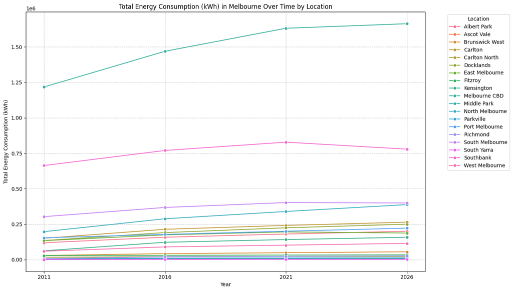

```python
# Group by Year and Location and sum the total energy consumption
annual_total_energy_by_location = df_energy_long.groupby(['Year', 'Location'])['Total_Energy_Consumption_kWh'].sum().reset_index()

plt.figure(figsize=(14, 8))
sns.lineplot(x='Year', y='Total_Energy_Consumption_kWh', hue='Location', data=annual_total_energy_by_location, marker='o')
plt.title('Total Energy Consumption (kWh) in Melbourne Over Time by Location')
plt.xlabel('Year')
plt.ylabel('Total Energy Consumption (kWh)')
plt.grid(True, linestyle='--', alpha=0.7)
plt.xticks(annual_total_energy_by_location['Year'].unique())
plt.legend(title='Location', bbox_to_anchor=(1.05, 1), loc='upper left')
plt.tight_layout()
plt.show()
```

### Energy Consumption by Building Type and Location

To get an even deeper understanding, let's also visualise how different building types contribute to the total energy consumption within each specific human-readable location, and if their trends vary. This can highlight specific areas and building types that are driving infrastructure demand.

### Deriving Building Type Information from Energy Consumption Data

Since the `df_environmental_resources` does not contain the building type information we're looking for, we will extract 'Commercial' and 'Residential' building types directly from our `df_energy_processed` dataframe. This involves a more detailed reshaping to separate the consumption values based on their type prefixes (`p_com_` and `p_res_`).

```python
import pandas as pd

# Get the processed dataframe for energy consumption
df_energy_processed = processed_dataframes['df_energy_consumption_processed'].copy()

# Identify columns for commercial and residential consumption
com_year_columns = [col for col in df_energy_processed.columns if 'p_com_' in col and col.replace('p_com_','') .isdigit()]
res_year_columns = [col for col in df_energy_processed.columns if 'p_res_' in col and col.replace('p_res_','') .isdigit()]

# Melt for Commercial consumption
df_com_long = df_energy_processed.melt(id_vars=['Geo Point', 'property_id', 'floor_area', 'Location'],
                                       value_vars=com_year_columns,
                                       var_name='Year_Str',
                                       value_name='Energy_Consumption_kWh')
df_com_long['Building Type'] = 'Commercial'
df_com_long['Year'] = df_com_long['Year_Str'].str.replace('p_com_', '').astype(int)

# Melt for Residential consumption
df_res_long = df_energy_processed.melt(id_vars=['Geo Point', 'property_id', 'floor_area', 'Location'],
                                       value_vars=res_year_columns,
                                       var_name='Year_Str',
                                       value_name='Energy_Consumption_kWh')
df_res_long['Building Type'] = 'Residential'
df_res_long['Year'] = df_res_long['Year_Str'].str.replace('p_res_', '').astype(int)

# Concatenate the commercial and residential dataframes
df_energy_long_typed = pd.concat([df_com_long, df_res_long], ignore_index=True)

# Convert 'Year' to datetime
df_energy_long_typed['Date'] = pd.to_datetime(df_energy_long_typed['Year'], format='%Y')

# Drop the original 'Year_Str' column
df_energy_long_typed = df_energy_long_typed.drop(columns=['Year_Str'])

print("Created df_energy_long_typed with Commercial and Residential building types.")
display(df_energy_long_typed.head())
print(df_energy_long_typed.info())
```

```
Created df_energy_long_typed with Commercial and Residential building types.
```

|  | Geo Point | property_id | floor_area | Location | Energy_Consumption_kWh | Building Type | Year | Date |
| --- | --- | --- | --- | --- | --- | --- | --- | --- |
| 0 | -37.83363154012436, 144.98420174077557 | 100431.0 | 762.96 | Richmond | 0.00000 | Commercial | 2011 | 2011-01-01 |
| 1 | -37.79900382289352, 144.93494112057527 | 100508.0 | 0.00 | West Melbourne | 338.76137 | Commercial | 2011 | 2011-01-01 |
| 2 | -37.800632838889626, 144.9488946131469 | 100521.0 | 286.40 | North Melbourne | 0.00000 | Commercial | 2011 | 2011-01-01 |
| 3 | -37.801031454537835, 144.95223929995998 | 100547.0 | 99.80 | North Melbourne | 0.00000 | Commercial | 2011 | 2011-01-01 |
| 4 | -37.8004776165655, 144.94154189092782 | 100550.0 | 0.00 | West Melbourne | 531.05895 | Commercial | 2011 | 2011-01-01 |

```
<class 'pandas.core.frame.DataFrame'>
RangeIndex: 108696 entries, 0 to 108695
Data columns (total 8 columns):
 #   Column                  Non-Null Count   Dtype
---  ------                  --------------   -----
 0   Geo Point               108696 non-null  object
 1   property_id             108696 non-null  float64
 2   floor_area              108696 non-null  float64
 3   Location                108696 non-null  object
 4   Energy_Consumption_kWh  108696 non-null  float64
 5   Building Type           108696 non-null  object
 6   Year                    108696 non-null  int64
 7   Date                    108696 non-null  datetime64[ns]
dtypes: datetime64[ns](1), float64(3), int64(1), object(3)
memory usage: 6.6+ MB
None
```

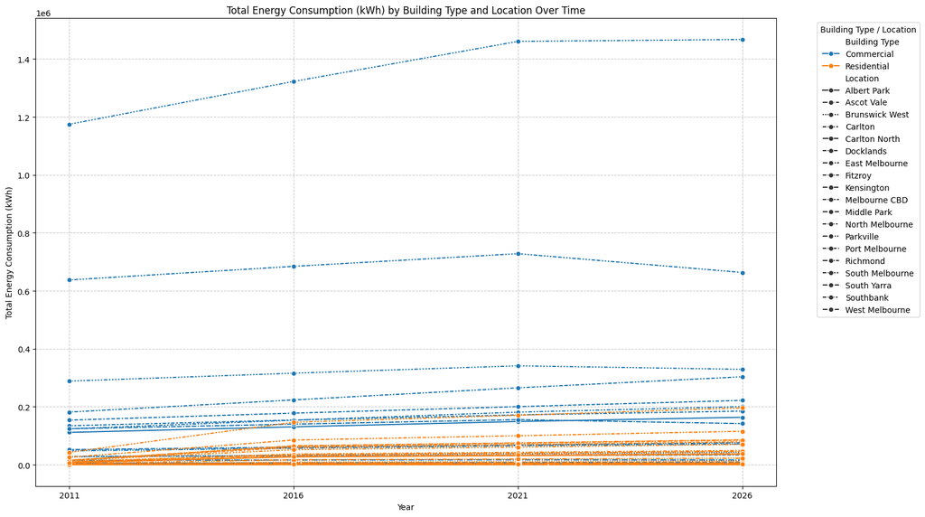

```python
energy_by_building_type_location = df_energy_long_typed.groupby(['Year', 'Building Type', 'Location'])['Energy_Consumption_kWh'].sum().reset_index()

plt.figure(figsize=(16, 9))
sns.lineplot(x='Year', y='Energy_Consumption_kWh', hue='Building Type', style='Location', data=energy_by_building_type_location, marker='o')
plt.title('Total Energy Consumption (kWh) by Building Type and Location Over Time')
plt.xlabel('Year')
plt.ylabel('Total Energy Consumption (kWh)')
plt.grid(True, linestyle='--', alpha=0.7)
plt.xticks(energy_by_building_type_location['Year'].unique())
plt.legend(title='Building Type / Location', bbox_to_anchor=(1.05, 1), loc='upper left')
plt.tight_layout()
plt.show()
```

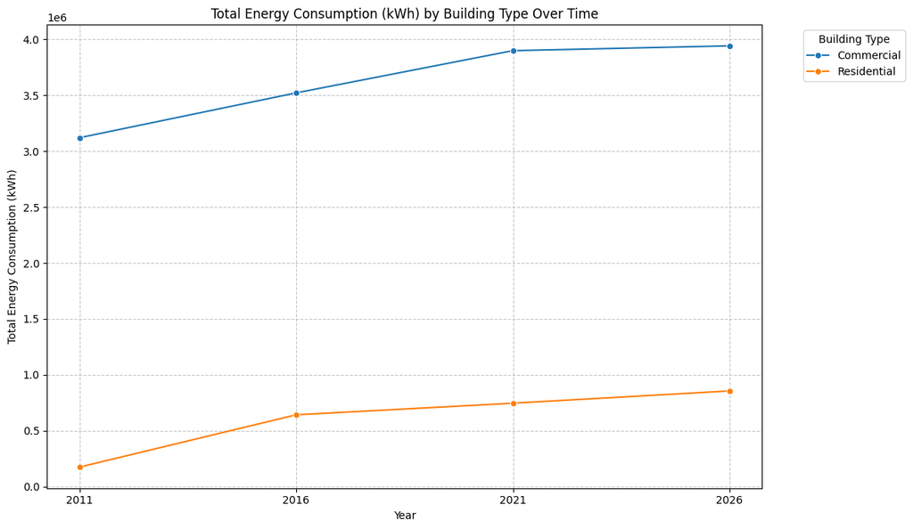

```python
import matplotlib.pyplot as plt
import seaborn as sns

# Group by Year and Building Type and sum the total energy consumption
energy_by_building_type = df_energy_long_typed.groupby(['Year', 'Building Type'])['Energy_Consumption_kWh'].sum().reset_index()

plt.figure(figsize=(12, 7))
sns.lineplot(x='Year', y='Energy_Consumption_kWh', hue='Building Type', data=energy_by_building_type, marker='o')
plt.title('Total Energy Consumption (kWh) by Building Type Over Time')
plt.xlabel('Year')
plt.ylabel('Total Energy Consumption (kWh)')
plt.grid(True, linestyle='--', alpha=0.7)
plt.xticks(energy_by_building_type['Year'].unique())
plt.legend(title='Building Type', bbox_to_anchor=(1.05, 1), loc='upper left')
plt.tight_layout()
plt.show()
```

## Forecasting Total Energy Consumption using LSTM

We will now attempt to forecast total energy consumption using a Long Short-Term Memory (LSTM) neural network. LSTMs are well-suited for time series forecasting tasks.

**Important Note on Data Limitations:** The `annual_total_energy` dataset, which we will use for this forecast, contains only 4 data points (representing total energy consumption for years 2011, 2016, 2021, and 2026). Training a deep learning model like an LSTM effectively requires significantly more data to learn underlying patterns and avoid overfitting. Therefore, the model's performance will be highly constrained by this limited data, and the forecasts should be interpreted with extreme caution and primarily as a demonstration of the methodology rather than a reliable prediction.

We will proceed with the following steps:

- Prepare the data by scaling and creating sequences.
- Define a simple LSTM model.
- Train the model.
- Generate and visualise predictions.

## Checking for Missing Values Across All Processed Dataframes

Before we proceed with feature engineering and model development, it's crucial to examine the completeness of our datasets. Identifying and understanding missing values will help us decide on appropriate imputation strategies or data cleaning steps.

```python
print("Checking for missing values in each processed dataframe...")

for df_name, df in processed_dataframes.items():
    print(f"\n--- Missing values in {df_name} ---")
    missing_values = df.isnull().sum()
    # Filter to show only columns with missing values and sort them
    missing_values = missing_values[missing_values > 0].sort_values(ascending=False)

    if not missing_values.empty:
        print("Found missing values in the following columns:")
        display(missing_values.to_frame(name='Missing Count'))
        print(f"Total missing values in {df_name}: {missing_values.sum()}")
    else:
        print("No missing values found in this dataframe.")

print("\nMissing value check complete.")
```

```
Checking for missing values in each processed dataframe...

--- Missing values in df_floor_space_processed ---
No missing values found in this dataframe.

--- Missing values in df_population_forecasts_processed ---
No missing values found in this dataframe.

--- Missing values in df_development_activity_processed ---
Found missing values in the following columns:
```

|  | Missing Count |
| --- | --- |
| property_id_5 | 1110 |
| property_id_4 | 1103 |
| property_id_3 | 1092 |
| property_id_2 | 1020 |

```
Total missing values in df_development_activity_processed: 4325

--- Missing values in df_environmental_resources_processed ---
Found missing values in the following columns:
```

|  | Missing Count |
| --- | --- |
| Off-peak amount | 7597 |
| Peak amount | 7462 |
| Amount | 6 |

```
Total missing values in df_environmental_resources_processed: 15065

--- Missing values in df_quality_of_life_processed ---
Found missing values in the following columns:
```

|  | Missing Count |
| --- | --- |
| Melbourne municipality (Units) | 87 |
| Greater Melbourne (Value) | 15 |
| Greater Melbourne (Year) | 15 |
| Greater Melbourne (Units) | 2 |

```
Total missing values in df_quality_of_life_processed: 119

--- Missing values in df_energy_consumption_processed ---
No missing values found in this dataframe.

Missing value check complete.
```

## Analysing and Visualising Trends in Population Forecasts

Following the request to explore other datasets and move towards advanced forecasting models, we will now analyse `df_population_forecasts_processed`. This dataset provides population forecasts by year, gender, and age group, making it an excellent candidate for time-series analysis. We'll start by visualising overall population trends and then discuss how this data could be prepared for models like Temporal Fusion Transformers or Hybrid Spatiotemporal models.

```
Population DataFrame info:
<class 'pandas.core.frame.DataFrame'>
RangeIndex: 10584 entries, 0 to 10583
Data columns (total 6 columns):
 #   Column      Non-Null Count  Dtype
---  ------      --------------  -----
 0   Geography  10584 non-null  object
 1   Year        10584 non-null  int64
 2   Gender      10584 non-null  object
 3   Age         10584 non-null  object
 4   Value       10584 non-null  int64
 5   Date        10584 non-null  datetime64[ns]
dtypes: datetime64[ns](1), int64(2), object(3)
memory usage: 496.3+ KB
```

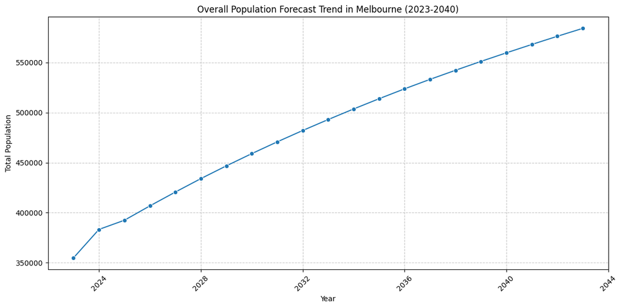

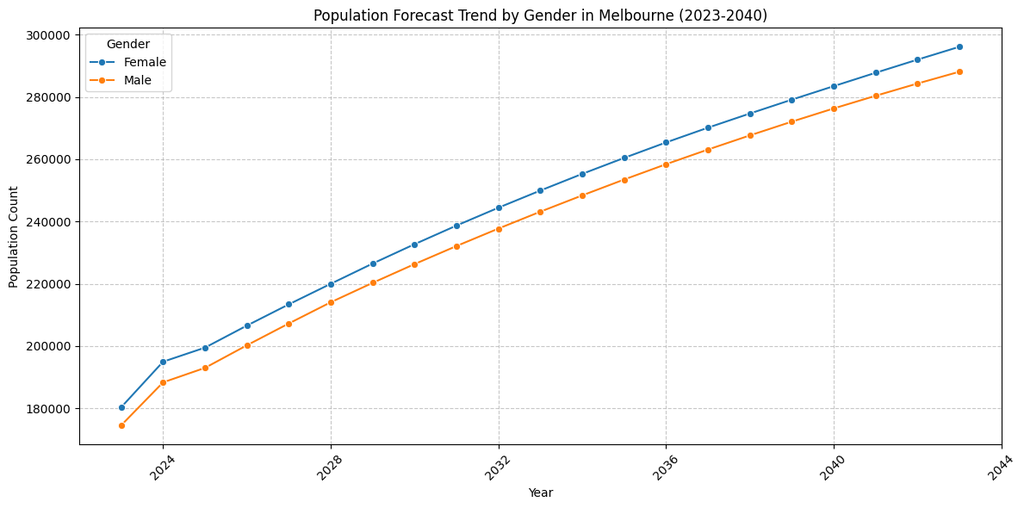

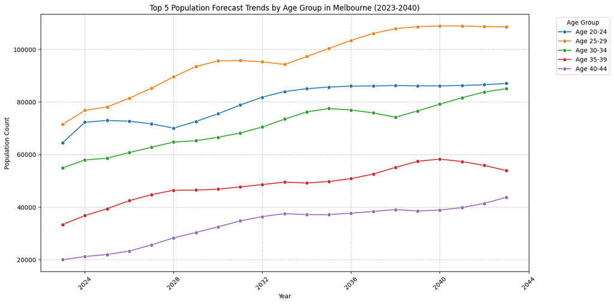

```python
import matplotlib.pyplot as plt
import seaborn as sns

# Ensure the 'Date' column is in datetime format and 'Value' is numeric
df_population = processed_dataframes['df_population_forecasts_processed'].copy()
df_population['Date'] = pd.to_datetime(df_population['Year'], format='%Y')
df_population['Value'] = pd.to_numeric(df_population['Value'])

print("Population DataFrame info:")
df_population.info()

# 1. Visualize Overall Population Trend
overall_population_trend = df_population.groupby('Date')['Value'].sum().reset_index()

plt.figure(figsize=(12, 6))
sns.lineplot(x='Date', y='Value', data=overall_population_trend, marker='o')
plt.title('Overall Population Forecast Trend in Melbourne (2023-2040)')
plt.xlabel('Year')
plt.ylabel('Total Population')
plt.grid(True, linestyle='--', alpha=0.7)
plt.xticks(rotation=45)
plt.tight_layout()
plt.show()

# 2. Visualize Population Trend by Gender
population_by_gender = df_population.groupby(['Date', 'Gender'])['Value'].sum().reset_index()

plt.figure(figsize=(12, 6))
sns.lineplot(x='Date', y='Value', hue='Gender', data=population_by_gender, marker='o')
plt.title('Population Forecast Trend by Gender in Melbourne (2023-2040)')
plt.xlabel('Year')
plt.ylabel('Population Count')
plt.grid(True, linestyle='--', alpha=0.7)
plt.xticks(rotation=45)
plt.legend(title='Gender')
plt.tight_layout()
plt.show()

# 3. Visualize Population Trend by Age Group (Top N for clarity)
# Get top N age groups based on latest year's population
latest_year = df_population['Year'].max()
top_age_groups = df_population[df_population['Year'] == latest_year].groupby('Age')['Value'].sum().nlargest(5).index
population_by_age = df_population[df_population['Age'].isin(top_age_groups)].groupby(['Date', 'Age'])['Value'].sum().reset_index()

plt.figure(figsize=(14, 7))
sns.lineplot(x='Date', y='Value', hue='Age', data=population_by_age, marker='o')
plt.title('Top 5 Population Forecast Trends by Age Group in Melbourne (2023-2040)')
plt.xlabel('Year')
plt.ylabel('Population Count')
plt.grid(True, linestyle='--', alpha=0.7)
plt.xticks(rotation=45)
plt.legend(title='Age Group', bbox_to_anchor=(1.05, 1), loc='upper left')
plt.tight_layout()
plt.show()
```

## Conceptual Data Structuring for Temporal Fusion Transformers (TFT)

Temporal Fusion Transformers (TFTs) are a powerful deep learning architecture for multi-horizon time series forecasting. They are designed to handle complex temporal dynamics, including multi-variate inputs, static (time-invariant) covariates, and dynamic (time-varying) covariates. Key requirements for TFTs include:

- **Time Index:** A clear time variable (e.g., `Date`).
- **Target Variable:** The variable to be forecasted (e.g., `Value` for population).
- **Grouping Variables (Entities):** Variables that define individual time series (e.g., `Geography`, `Gender`, `Age`). A TFT can forecast multiple series simultaneously.
- **Static Covariates:** Features that do not change over time for a given entity (e.g., `Geography` might be treated as static if its characteristics are constant for the forecast horizon).
- **Dynamic Covariates:** Features that change over time, both known in the future (e.g., `Year`, `Month` if doing sub-annual forecasts) and unknown in the future (e.g., economic indicators).

For `df_population_forecasts_processed`, we could structure the data as follows:

- **Time Index:** `Date`
- **Target:** `Value`
- **Grouping Variables:** `Geography`, `Gender`, `Age` (as each combination defines a unique series)
- **Static Covariates:** `Geography` (as an embedding)
- **Dynamic Covariates (known in future):** `Year` (derived from `Date`). Other potential features like `Gender` and `Age` can also be considered dynamic if their influence is modelled as time-varying.

Libraries like `pytorch_forecasting` provide excellent tools to prepare data into the specific `TimeSeriesDataSet` format required by TFTs. This involves defining all the above components and handling features like embeddings for categorical variables and scaling for numerical ones. A full implementation would involve defining the `TimeSeriesDataSet`, then instantiating and training a `TemporalFusionTransformer` model.

```python
print("Checking for missing values in each processed dataframe...")

for df_name, df in processed_dataframes.items():
    print(f"\n--- Missing values in {df_name} ---")
    missing_values = df.isnull().sum()
    # Filter to show only columns with missing values and sort them
    missing_values = missing_values[missing_values > 0].sort_values(ascending=False)

    if not missing_values.empty:
        print("Found missing values in the following columns:")
        display(missing_values.to_frame(name='Missing Count'))
        print(f"Total missing values in {df_name}: {missing_values.sum()}")
    else:
        print("No missing values found in this dataframe.")

print("\nMissing value check complete.")
```

```
Checking for missing values in each processed dataframe...

--- Missing values in df_floor_space_processed ---
No missing values found in this dataframe.

--- Missing values in df_population_forecasts_processed ---
No missing values found in this dataframe.

--- Missing values in df_development_activity_processed ---
Found missing values in the following columns:
```

|  | Missing Count |
| --- | --- |
| property_id_5 | 1110 |
| property_id_4 | 1103 |
| property_id_3 | 1092 |
| property_id_2 | 1020 |

```
Total missing values in df_development_activity_processed: 4325

--- Missing values in df_environmental_resources_processed ---
Found missing values in the following columns:
```

|  | Missing Count |
| --- | --- |
| Off-peak amount | 7597 |
| Peak amount | 7462 |
| Amount | 6 |

```
Total missing values in df_environmental_resources_processed: 15065

--- Missing values in df_quality_of_life_processed ---
Found missing values in the following columns:
```

|  | Missing Count |
| --- | --- |
| Melbourne municipality (Units) | 87 |
| Greater Melbourne (Value) | 15 |
| Greater Melbourne (Year) | 15 |
| Greater Melbourne (Units) | 2 |

```
Total missing values in df_quality_of_life_processed: 119

--- Missing values in df_energy_consumption_processed ---
No missing values found in this dataframe.

Missing value check complete.
```

```python
import numpy as np
from sklearn.preprocessing import MinMaxScaler
from tensorflow.keras.models import Sequential
from tensorflow.keras.layers import LSTM, Dense

# Extract the energy consumption values
data = annual_total_energy['Total_Energy_Consumption_kWh'].values.reshape(-1, 1)

# Scale the data
scaler = MinMaxScaler(feature_range=(0, 1))
scaled_data = scaler.fit_transform(data)

# Function to create sequences for LSTM
def create_sequences(data, look_back=1):
    X, y = [], []
    for i in range(len(data) - look_back):
        X.append(data[i:(i + look_back), 0])
        y.append(data[i + look_back, 0])
    return np.array(X), np.array(y)

# For this very small dataset, a look_back of 1 is the most feasible.
# A larger look_back would leave too few samples for training.
look_back = 1
X, y = create_sequences(scaled_data, look_back)

# Reshape input to be [samples, time steps, features]
X = np.reshape(X, (X.shape[0], X.shape[1], 1))

print(f"Original data points: {len(data)}")
print(f"Data points after creating sequences (X, y): {len(X)}")
print(f"Shape of X for LSTM: {X.shape}")
print(f"Shape of y for LSTM: {y.shape}")

print("Data prepared for LSTM model.")
```

```
Original data points: 4
Data points after creating sequences (X, y): 3
Shape of X for LSTM: (3, 1, 1)
Shape of y for LSTM: (3,)
Data prepared for LSTM model.
```

```python
# Build the LSTM model
model = Sequential()
model.add(LSTM(units=50, activation='relu', input_shape=(look_back, 1)))
model.add(Dense(units=1))
model.compile(optimizer='adam', loss='mean_squared_error')

model.summary()

# Train the model
# Due to extremely limited data, epochs and batch_size are set low for demonstration.
# In a real-world scenario with more data, these would be significantly higher.
print("\nTraining the LSTM model...")
model.fit(X, y, epochs=50, batch_size=1, verbose=0) # Set verbose to 0 to suppress output per epoch
print("Model training complete.")
```

```
Model: "sequential_1"
```

```
┏━━━━━━━━━━━━━━━━━━━━━━━━━━━━━━━━━┳━━━━━━━━━━━━━━━━━━━━━━━━┳━━━━━━━━━━━━━━━┓
┃ Layer (type)                    ┃ Output Shape           ┃       Param # ┃
┡━━━━━━━━━━━━━━━━━━━━━━━━━━━━━━━━━╇━━━━━━━━━━━━━━━━━━━━━━━━╇━━━━━━━━━━━━━━━┩
│ lstm_1 (LSTM)                   │ (None, 50)             │        10,400 │
├─────────────────────────────────┼────────────────────────┼───────────────┤
│ dense_1 (Dense)                 │ (None, 1)              │            51 │
└─────────────────────────────────┴────────────────────────┴───────────────┘
```

```
 Total params: 10,451 (40.82 KB)
```

```
 Trainable params: 10,451 (40.82 KB)
```

```
 Non-trainable params: 0 (0.00 B)
```

```
Training the LSTM model...
Model training complete.
```

```
1/1 ━━━━━━━━━━━━━━━━━━━━ 0s 129ms/step
1/1 ━━━━━━━━━━━━━━━━━━━━ 0s 134ms/step
1/1 ━━━━━━━━━━━━━━━━━━━━ 0s 27ms/step
```

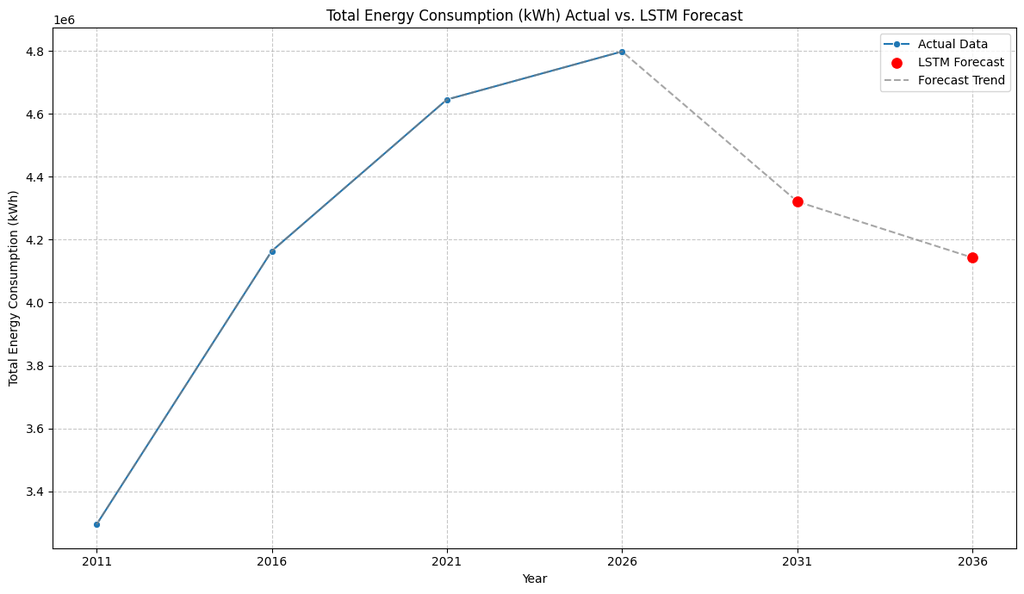

```
LSTM Forecasting complete. Please review the plot and consider the data limitations mentioned earlier.
```

```python
# Make predictions
# We will use the last available data point to predict the next future step
# Then use that prediction to predict the step after, and so on.

# First, predict on the existing data to see how well it fits
predicted_scaled = model.predict(X)
predicted_original = scaler.inverse_transform(predicted_scaled)

# For forecasting future values, we need to create an input sequence for the next year
# Given our data points are sparse (2011, 2016, 2021, 2026), predicting 2031 (next 5-year interval)
last_value_scaled = scaled_data[-1].reshape(1, look_back, 1)

future_predictions_scaled = []
num_future_steps = 2 # Predict for 2031 and 2036
current_input = last_value_scaled

for _ in range(num_future_steps):
    next_prediction_scaled = model.predict(current_input)
    future_predictions_scaled.append(next_prediction_scaled[0, 0])
    # Update input for the next prediction: the new input sequence includes the latest prediction
    current_input = np.append(current_input[:, 1:, :], next_prediction_scaled.reshape(1, 1, 1), axis=1)
    # If look_back > 1, this needs adjustment to correctly slide the window.
    # For look_back=1, it's just the previous prediction.

future_predictions_original = scaler.inverse_transform(np.array(future_predictions_scaled).reshape(-1, 1))

# Prepare data for plotting
train_years = annual_total_energy['Year'].iloc[look_back:].values
train_actual = annual_total_energy['Total_Energy_Consumption_kWh'].iloc[look_back:].values

# Create a full range of years including future predictions
all_years = list(annual_total_energy['Year'].values)
last_year = all_years[-1]
for i in range(1, num_future_steps + 1):
    all_years.append(last_year + (i * 5)) # Assuming 5-year intervals

# Combine actual and future predictions for plotting
plot_data_actual = annual_total_energy.copy()

future_years = [last_year + (i * 5) for i in range(1, num_future_steps + 1)]
future_df = pd.DataFrame({
    'Year': future_years,
    'Total_Energy_Consumption_kWh': future_predictions_original.flatten()
})

forecast_df = pd.concat([plot_data_actual, future_df], ignore_index=True)

# Visualize the results
plt.figure(figsize=(12, 7))
sns.lineplot(x='Year', y='Total_Energy_Consumption_kWh', data=plot_data_actual, marker='o', label='Actual Data')
sns.scatterplot(x='Year', y='Total_Energy_Consumption_kWh', data=future_df, color='red', s=100, zorder=5, label='LSTM Forecast')
plt.plot(forecast_df['Year'], forecast_df['Total_Energy_Consumption_kWh'], linestyle='--', color='gray', alpha=0.7, label='Forecast Trend')

plt.title('Total Energy Consumption (kWh) Actual vs. LSTM Forecast')
plt.xlabel('Year')
plt.ylabel('Total Energy Consumption (kWh)')
plt.grid(True, linestyle='--', alpha=0.7)
plt.xticks(all_years) # Ensure all years including future ones are shown
plt.legend()
plt.tight_layout()
plt.show()

print("\nLSTM Forecasting complete. Please review the plot and consider the data limitations mentioned earlier.")
```

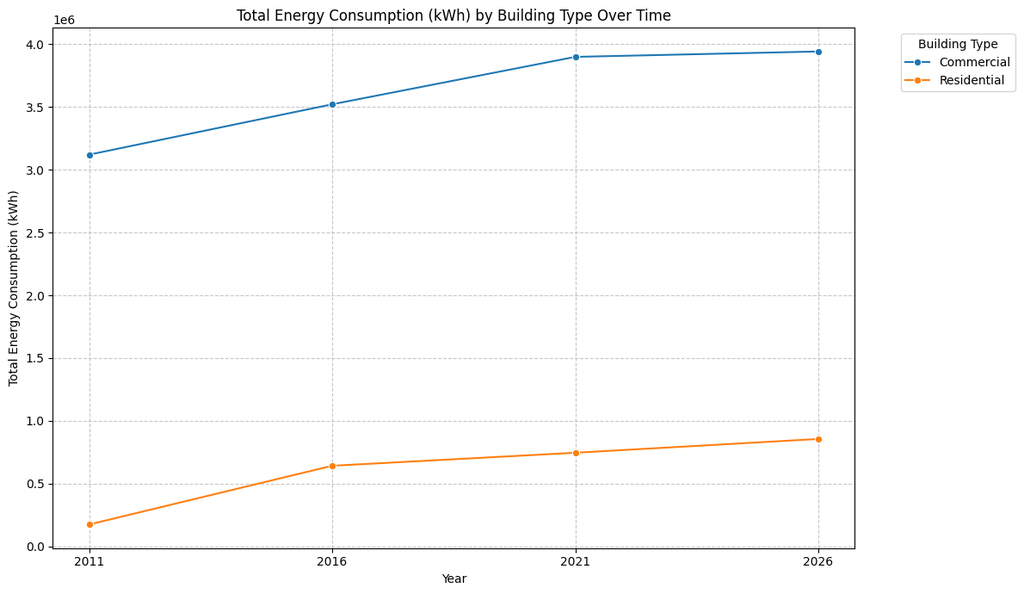

```python
import matplotlib.pyplot as plt
import seaborn as sns

# Group by Year and Building Type and sum the total energy consumption
energy_by_building_type = df_energy_long_typed.groupby(['Year', 'Building Type'])['Energy_Consumption_kWh'].sum().reset_index()

plt.figure(figsize=(12, 7))
sns.lineplot(x='Year', y='Energy_Consumption_kWh', hue='Building Type', data=energy_by_building_type, marker='o')
plt.title('Total Energy Consumption (kWh) by Building Type Over Time')
plt.xlabel('Year')
plt.ylabel('Total Energy Consumption (kWh)')
plt.grid(True, linestyle='--', alpha=0.7)
plt.xticks(energy_by_building_type['Year'].unique())
plt.legend(title='Building Type', bbox_to_anchor=(1.05, 1), loc='upper left')
plt.tight_layout()
plt.show()
```

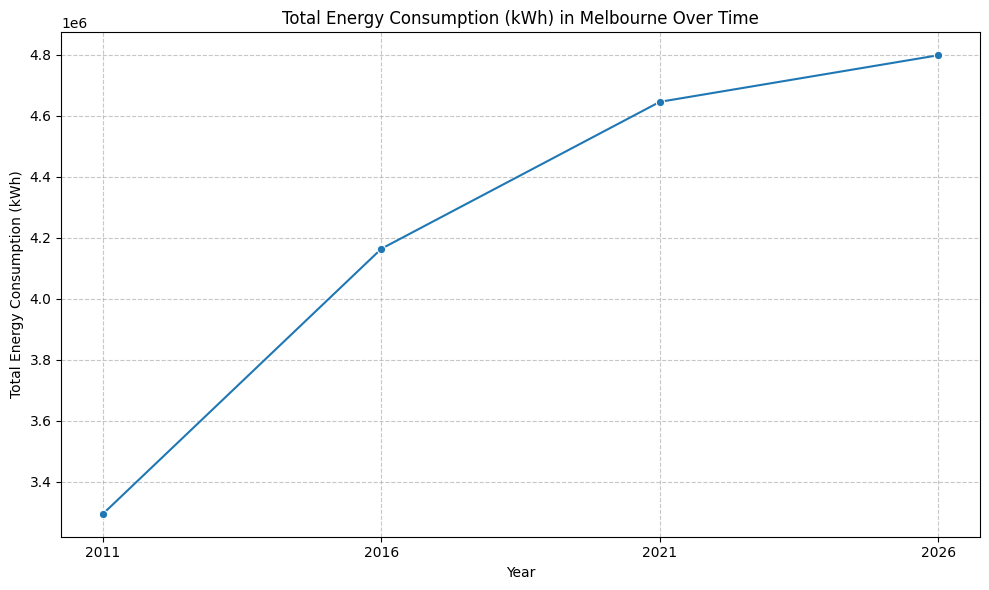

```python
# Group by year and sum the total energy consumption
annual_total_energy = df_energy_long.groupby('Year')['Total_Energy_Consumption_kWh'].sum().reset_index()

plt.figure(figsize=(10, 6))
sns.lineplot(x='Year', y='Total_Energy_Consumption_kWh', data=annual_total_energy, marker='o')
plt.title('Total Energy Consumption (kWh) in Melbourne Over Time')
plt.xlabel('Year')
plt.ylabel('Total Energy Consumption (kWh)')
plt.grid(True, linestyle='--', alpha=0.7)
plt.xticks(annual_total_energy['Year'].unique())
plt.tight_layout()
plt.show()
```

```python
!pip install tqdm
```

```python
import pandas as pd
import matplotlib.pyplot as plt
import seaborn as sns

# Get the processed dataframe for energy consumption
df_energy_processed = processed_dataframes['df_energy_consumption_processed'].copy()

print("Columns in df_energy_processed:")
print(df_energy_processed.columns)

# Identify columns that represent energy consumption for different years
year_columns = [col for col in df_energy_processed.columns if 'total_' in col and col.replace('total_','') .isdigit()]

# Reshape the dataframe using `melt` to convert year columns into rows
# Now include 'Location' along with 'Geo Point' as id_vars
df_energy_long = df_energy_processed.melt(id_vars=['Geo Point', 'Location'],
                                          value_vars=year_columns,
                                          var_name='Year_Str',
                                          value_name='Total_Energy_Consumption_kWh')

# Extract the year from the 'Year_Str' column and convert to datetime
df_energy_long['Year'] = df_energy_long['Year_Str'].str.replace('total_', '').astype(int)
df_energy_long['Date'] = pd.to_datetime(df_energy_long['Year'], format='%Y')

# Drop the original 'Year_Str' column as we now have 'Year' and 'Date'
df_energy_long = df_energy_long.drop(columns=['Year_Str'])

print("Reshaped df_energy_consumption_processed into a time-series friendly format, including Location.")
display(df_energy_long.head())
print(df_energy_long.info())
```

```
Columns in df_energy_processed:
Index(['Geo Point', 'Suburb', 'Latitude', 'Longitude', 'Geo Shape',
       'total_2011', 'p_com_2011', 'p_res_2026', 'p_com_2026', 'total_2026',
       'p_com_2021', 'property_id', 'p_res_2011', 'total_2016', 'total_2021',
       'p_res_2021', 'floor_area', 'p_res_2016', 'p_com_2016', 'Location'],
      dtype='object')
Reshaped df_energy_consumption_processed into a time-series friendly format, including Location.
```

|  | Geo Point | Location | Total_Energy_Consumption_kWh | Year | Date |
| --- | --- | --- | --- | --- | --- |
| 0 | -37.83363154012436, 144.98420174077557 | Richmond | 15.836556 | 2011 | 2011-01-01 |
| 1 | -37.79900382289352, 144.93494112057527 | West Melbourne | 338.761383 | 2011 | 2011-01-01 |
| 2 | -37.800632838889626, 144.9488946131469 | North Melbourne | 19.007585 | 2011 | 2011-01-01 |
| 3 | -37.801031454537835, 144.95223929995998 | North Melbourne | 2.376923 | 2011 | 2011-01-01 |
| 4 | -37.8004776165655, 144.94154189092782 | West Melbourne | 531.058950 | 2011 | 2011-01-01 |

```
<class 'pandas.core.frame.DataFrame'>
RangeIndex: 54348 entries, 0 to 54347
Data columns (total 5 columns):
 #   Column                        Non-Null Count  Dtype
---  ------                        --------------  -----
 0   Geo Point                     54348 non-null  object
 1   Location                      54348 non-null  object
 2   Total_Energy_Consumption_kWh  54348 non-null  float64
 3   Year                          54348 non-null  int64
 4   Date                          54348 non-null  datetime64[ns]
dtypes: datetime64[ns](1), float64(1), int64(1), object(2)
memory usage: 2.1+ MB
None
```

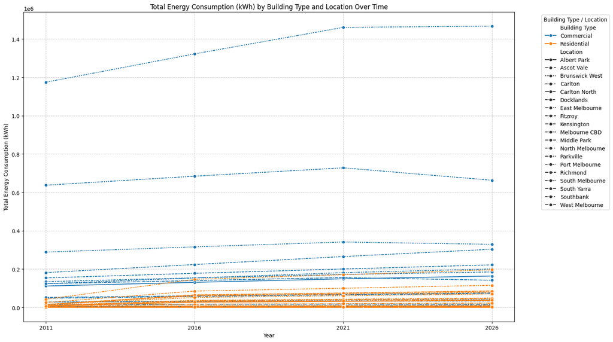

```python
energy_by_building_type_location = df_energy_long_typed.groupby(['Year', 'Building Type', 'Location'])['Energy_Consumption_kWh'].sum().reset_index()

plt.figure(figsize=(16, 9))
sns.lineplot(x='Year', y='Energy_Consumption_kWh', hue='Building Type', style='Location', data=energy_by_building_type_location, marker='o')
plt.title('Total Energy Consumption (kWh) by Building Type and Location Over Time')
plt.xlabel('Year')
plt.ylabel('Total Energy Consumption (kWh)')
plt.grid(True, linestyle='--', alpha=0.7)
plt.xticks(energy_by_building_type_location['Year'].unique())
plt.legend(title='Building Type / Location', bbox_to_anchor=(1.05, 1), loc='upper left')
plt.tight_layout()
plt.show()
```

```python
import pandas as pd

# Dictionary of all loaded dataframes, including the original ones
all_dataframes = {
    'df_floor_space': df_floor_space,
    'df_population_forecasts': df_population_forecasts,
    'df_development_activity': df_development_activity,
    'df_environmental_resources': df_environmental_resources,
    'df_quality_of_life': df_quality_of_life,
    'df_energy_consumption': df_energy_consumption
}

# List to keep track of processed dataframes
processed_dataframes = {}

print("Starting date column standardization and initial inspection...")

for df_name, df in all_dataframes.items():
    df_copy = df.copy() # Work on a copy to avoid modifying original DFs directly
    print(f"\n--- Processing {df_name} ---")

    # Identify potential date/year columns and convert them
    if 'Year' in df_copy.columns:
        # For dataframes with a 'Year' column, convert it to datetime objects representing the start of the year
        df_copy['Date'] = pd.to_datetime(df_copy['Year'], format='%Y')
        print(f"Converted 'Year' column to 'Date' (datetime) in {df_name}.")
    elif 'year_completed' in df_copy.columns:
        # For df_development_activity, 'year_completed' can be a date reference
        df_copy['Date'] = pd.to_datetime(df_copy['year_completed'], format='%Y', errors='coerce')
        print(f"Converted 'year_completed' to 'Date' (datetime) in {df_name}.")
        # Drop rows where 'year_completed' couldn't be coerced to a valid date
        df_copy.dropna(subset=['Date'], inplace=True)
    elif 'Billing Start date' in df_copy.columns:
        # For environmental resources, use 'Billing Start date'
        df_copy['Date'] = pd.to_datetime(df_copy['Billing Start date'], errors='coerce')
        print(f"Converted 'Billing Start date' to 'Date' (datetime) in {df_name}.")
        df_copy.dropna(subset=['Date'], inplace=True)
    elif 'Melbourne municipality (Year)' in df_copy.columns:
        # For quality of life, use 'Melbourne municipality (Year)'
        df_copy['Date'] = pd.to_datetime(df_copy['Melbourne municipality (Year)'], format='%Y', errors='coerce')
        print(f"Converted 'Melbourne municipality (Year)' to 'Date' (datetime) in {df_name}.")
        df_copy.dropna(subset=['Date'], inplace=True)
    elif 'total_2011' in df_copy.columns and 'total_2016' in df_copy.columns and 'total_2021' in df_copy.columns:
        # For df_energy_consumption, this looks like a snapshot rather than a time-series per row.
        # We might need to reshape this later, but for now, just acknowledge its structure.
        print(f"{df_name} contains year-specific columns like 'total_2011', 'total_2016', etc. This might require reshaping into a time-series format later.")
    else:
        print(f"No obvious date/year column found for direct conversion in {df_name}. Further investigation may be needed.")

    # Display info and first few rows of the processed dataframe
    print(df_copy.info())
    display(df_copy.head())

    processed_dataframes[df_name + '_processed'] = df_copy

print("\nDate standardization and initial inspection complete.")
```

```
Starting date column standardization and initial inspection...

--- Processing df_floor_space ---
Converted 'Year' column to 'Date' (datetime) in df_floor_space.
<class 'pandas.core.frame.DataFrame'>
RangeIndex: 9345 entries, 0 to 9344
Data columns (total 6 columns):
 #   Column              Non-Null Count  Dtype
---  ------              --------------  -----
 0   Geography          9345 non-null   object
 1   Year                9345 non-null   int64
 2   Category            9345 non-null   object
 3   Industry Space Use  9345 non-null   object
 4   Value               9345 non-null   int64
 5   Date                9345 non-null   datetime64[ns]
dtypes: datetime64[ns](1), int64(2), object(3)
memory usage: 438.2+ KB
None
```

|  | Geography | Year | Category | Industry Space Use | Value | Date |
| --- | --- | --- | --- | --- | --- | --- |
| 0 | Carlton | 2023 | Residential floorspace by space use | apartment | 680226 | 2023-01-01 |
| 1 | Carlton | 2038 | Residential floorspace by space use | house | 231953 | 2038-01-01 |
| 2 | Docklands | 2028 | Residential floorspace by space use | apartment | 975903 | 2028-01-01 |
| 3 | Docklands | 2023 | Residential floorspace by space use | house | 60279 | 2023-01-01 |
| 4 | Docklands | 2026 | Residential floorspace by space use | house | 60279 | 2026-01-01 |

```
--- Processing df_population_forecasts ---
Converted 'Year' column to 'Date' (datetime) in df_population_forecasts.
<class 'pandas.core.frame.DataFrame'>
RangeIndex: 10584 entries, 0 to 10583
Data columns (total 6 columns):
 #   Column      Non-Null Count  Dtype
---  ------      --------------  -----
 0   Geography  10584 non-null  object
 1   Year        10584 non-null  int64
 2   Gender      10584 non-null  object
 3   Age         10584 non-null  object
 4   Value       10584 non-null  int64
 5   Date        10584 non-null  datetime64[ns]
dtypes: datetime64[ns](1), int64(2), object(3)
memory usage: 496.3+ KB
None
```

|  | Geography | Year | Gender | Age | Value | Date |
| --- | --- | --- | --- | --- | --- | --- |
| 0 | Kensington | 2037 | Male | Age 45-49 | 747 | 2037-01-01 |
| 1 | Kensington | 2038 | Female | Age 20-24 | 428 | 2038-01-01 |
| 2 | Kensington | 2038 | Female | Age 75-79 | 144 | 2038-01-01 |
| 3 | Kensington | 2038 | Male | Age 50-54 | 267 | 2038-01-01 |
| 4 | Kensington | 2038 | Male | Age 75-79 | 172 | 2038-01-01 |

```
--- Processing df_development_activity ---
Converted 'year_completed' to 'Date' (datetime) in df_development_activity.
<class 'pandas.core.frame.DataFrame'>
Index: 1110 entries, 0 to 1448
Data columns (total 43 columns):
 #   Column                       Non-Null Count  Dtype
---  ------                       --------------  -----
 0   data_format                  1110 non-null   object
 1   development_key              1110 non-null   object
 2   status                       1110 non-null   object
 3   year_completed               1110 non-null   float64
 4   clue_small_area              1110 non-null   object
 5   clue_block                   1110 non-null   int64
 6   street_address               1110 non-null   object
 7   property_id                  1110 non-null   int64
```

[output cut: 38 more lines]

|  | data_format | development_key | status | year_completed | clue_small_area | clue_block | street_address | property_id | property_id_2 | property_id_3 | ... | recreation_flr | publicdispaly_flr | community_flr | car_spaces | bike_spaces | town_planning_application | longitude | latitude | geopoint | Date |
| --- | --- | --- | --- | --- | --- | --- | --- | --- | --- | --- | --- | --- | --- | --- | --- | --- | --- | --- | --- | --- | --- |
| 0 | Pre May 16 | X000459 | COMPLETED | 2005.0 | North Melbourne | 333 | 218-224 Abbotsford Street NORTH MELBOURNE VIC ... | 100119 | NaN | NaN | ... | 0 | 0 | 0 | 0 | 0 | 0 | 144.945947 | -37.802049 | -37.80204879, 144.9459475 | 2005-01-01 |
| 1 | Pre May 16 | X000573 | COMPLETED | 2013.0 | West Melbourne (Residential) | 414 | 56-62 Abbotsford Street WEST MELBOURNE VIC 3003 | 100144 | NaN | NaN | ... | 0 | 0 | 0 | 0 | 0 | 0 | 144.944719 | -37.806791 | -37.80679128, 144.9447186 | 2013-01-01 |
| 2 | Pre May 16 | X000448 | COMPLETED | 2015.0 | North Melbourne | 314 | 302-308 Arden Street NORTH MELBOURNE VIC 3051 | 100509 | NaN | NaN | ... | 0 | 0 | 0 | 24 | 6 | 0 | 144.937724 | -37.799250 | -37.79925034, 144.9377236 | 2015-01-01 |
| 3 | Pre May 16 | X000449 | COMPLETED | 2009.0 | North Melbourne | 315 | North Melbourne Recreation Reserve 204-206 Ard... | 100514 | NaN | NaN | ... | 2494 | 0 | 0 | 0 | 0 | 0 | 144.941433 | -37.798926 | -37.79892607, 144.9414326 | 2009-01-01 |
| 4 | Pre May 16 | X000394 | COMPLETED | 2002.0 | Carlton | 257 | 16-18 Barkly Place CARLTON VIC 3053 | 100734 | NaN | NaN | ... | 0 | 0 | 0 | 0 | 0 | 0 | 144.961420 | -37.803201 | -37.80320056, 144.9614195 | 2002-01-01 |

5 rows × 43 columns

```
--- Processing df_environmental_resources ---
Converted 'Billing Start date' to 'Date' (datetime) in df_environmental_resources.
<class 'pandas.core.frame.DataFrame'>
RangeIndex: 9474 entries, 0 to 9473
Data columns (total 13 columns):
 #   Column                            Non-Null Count  Dtype
---  ------                            --------------  -----
 0   Branch                            9474 non-null   object
 1   Asset Name                        9474 non-null   object
 2   Resource Category                 9474 non-null   object
 3   Resource Type                     9474 non-null   object
 4   Amount                            9468 non-null   float64
 5   Unit                              9474 non-null   object
 6   Total Greenhouse Gases (t CO2-e)  9474 non-null   float64
 7   Billing Start date                9474 non-null   object
 8   Billing End Date                  9474 non-null   object
 9   CoM or Supply Chain               9474 non-null   object
 10  Peak amount                       2012 non-null   float64
 11  Off-peak amount                   1877 non-null   float64
 12  Date                              9474 non-null   datetime64[ns]
dtypes: datetime64[ns](1), float64(4), object(8)
memory usage: 962.3+ KB
None
```

|  | Branch | Asset Name | Resource Category | Resource Type | Amount | Unit | Total Greenhouse Gases (t CO2-e) | Billing Start date | Billing End Date | CoM or Supply Chain | Peak amount | Off-peak amount | Date |
| --- | --- | --- | --- | --- | --- | --- | --- | --- | --- | --- | --- | --- | --- |
| 0 | Property Services | Toilets - Flinders Street Station | Water | Water | 81.629630 | kL | 111.016296 | 2014-06-01 | 2014-06-30 | CoM | NaN | NaN | 2014-06-01 |
| 1 | Property Services | Toilets - Queen Street | Water | Water | 44.800549 | kL | 60.928746 | 2014-06-01 | 2014-06-30 | CoM | NaN | NaN | 2014-06-01 |
| 2 | Property Services | Lease - Multicultural Hub | Water | Water | 72.844216 | kL | 99.068133 | 2014-06-01 | 2014-06-30 | CoM | NaN | NaN | 2014-06-01 |
| 3 | Property Services | Lease - Aged Care Facility - Melrose St | Water | Water | 0.000000 | kL | 0.000000 | 2013-09-01 | 2013-09-30 | CoM | NaN | NaN | 2013-09-01 |
| 4 | Property Services | Lease - 236 Little Collins Street - Ch2 Shop | Water | Water | 0.000000 | kL | 0.000000 | 2014-04-01 | 2014-04-30 | CoM | NaN | NaN | 2014-04-01 |

```
--- Processing df_quality_of_life ---
Converted 'Melbourne municipality (Year)' to 'Date' (datetime) in df_quality_of_life.
<class 'pandas.core.frame.DataFrame'>
Index: 87 entries, 0 to 99
Data columns (total 12 columns):
 #   Column                          Non-Null Count  Dtype
---  ------                          --------------  -----
 0   Number                          87 non-null     float64
 1   Indicator Theme                 87 non-null     object
 2   Indicator Variable              87 non-null     object
 3   Indicator Descriptor            87 non-null     object
 4   Type                            87 non-null     object
 5   Greater Melbourne (Value)       72 non-null     float64
 6   Greater Melbourne (Year)        72 non-null     float64
 7   Greater Melbourne (Units)       85 non-null     object
 8   Melbourne municipality (Value)  87 non-null     float64
 9   Melbourne municipality (Year)   87 non-null     float64
 10  Melbourne municipality (Units)  0 non-null      float64
 11  Date                            87 non-null     datetime64[ns]
dtypes: datetime64[ns](1), float64(6), object(5)
memory usage: 8.8+ KB
None
```

|  | Number | Indicator Theme | Indicator Variable | Indicator Descriptor | Type | Greater Melbourne (Value) | Greater Melbourne (Year) | Greater Melbourne (Units) | Melbourne municipality (Value) | Melbourne municipality (Year) | Melbourne municipality (Units) | Date |
| --- | --- | --- | --- | --- | --- | --- | --- | --- | --- | --- | --- | --- |
| 0 | 5.4 | Economy | Full-time Employment | Percentage of persons in fulltime employment | Supporting | 50.6319 | 2014.0 | % | 58.5449 | 2014.0 | NaN | 2014-01-01 |
| 1 | 5.7 | Economy | Number of New Patents | Number of new patents per 100 000 population p... | Supporting | 13.6251 | 2014.0 | /100 000/yr | 84.2832 | 2014.0 | NaN | 2014-01-01 |
| 2 | 6.3 | Education | Secondary Education Completion | Percentage of students completing secondary ed... | Core | 91.8848 | 2013.0 | % | 70.0492 | 2013.0 | NaN | 2013-01-01 |
| 3 | 7.1 | Energy | Residential Electrical Use | Total residential electrical energy use per ca... | Core | NaN | NaN | kWh/yr/capita | 1730.8241 | 2015.0 | NaN | 2015-01-01 |
| 4 | 7.7 | Energy | Electrical Interruption Length | Average length of electrical interruptions (in... | Supporting | 1.6329 | 2010.0 | hours | 1.8827 | 2010.0 | NaN | 2010-01-01 |

```
--- Processing df_energy_consumption ---
df_energy_consumption contains year-specific columns like 'total_2011', 'total_2016', etc. This might require reshaping into a time-series format later.
<class 'pandas.core.frame.DataFrame'>
RangeIndex: 13587 entries, 0 to 13586
Data columns (total 19 columns):
 #   Column       Non-Null Count  Dtype
---  ------       --------------  -----
 0   Geo Point    13587 non-null  object
 1   Suburb       13587 non-null  object
 2   Latitude     13587 non-null  float64
 3   Longitude    13587 non-null  float64
 4   Geo Shape    13587 non-null  object
 5   total_2011   13587 non-null  float64
 6   p_com_2011   13587 non-null  float64
 7   p_res_2026   13587 non-null  float64
 8   p_com_2026   13587 non-null  float64
 9   total_2026   13587 non-null  float64
 10  p_com_2021   13587 non-null  float64
 11  property_id  13587 non-null  float64
 12  p_res_2011   13587 non-null  float64
 13  total_2016   13587 non-null  float64
 14  total_2021   13587 non-null  float64
 15  p_res_2021   13587 non-null  float64
 16  floor_area   13587 non-null  float64
 17  p_res_2016   13587 non-null  float64
 18  p_com_2016   13587 non-null  float64
dtypes: float64(16), object(3)
memory usage: 2.0+ MB
None
```

|  | Geo Point | Suburb | Latitude | Longitude | Geo Shape | total_2011 | p_com_2011 | p_res_2026 | p_com_2026 | total_2026 | p_com_2021 | property_id | p_res_2011 | total_2016 | total_2021 | p_res_2021 | floor_area | p_res_2016 | p_com_2016 |
| --- | --- | --- | --- | --- | --- | --- | --- | --- | --- | --- | --- | --- | --- | --- | --- | --- | --- | --- | --- |
| 0 | -37.83363154012436, 144.98420174077557 | Richmond | -37.833632 | 144.984202 | {"coordinates": [[[[144.98447264054937, -37.83... | 15.836556 | 0.00000 | 57.617929 | 0.000000 | 57.617929 | 0.000000 | 100431.0 | 15.836556 | 43.873253 | 50.745591 | 50.745591 | 762.96 | 43.873253 | 0.000000 |
| 1 | -37.79900382289352, 144.93494112057527 | West Melbourne | -37.799004 | 144.934941 | {"coordinates": [[[[144.93552203684675, -37.79... | 338.761383 | 338.76137 | 0.000000 | 426.318301 | 426.318301 | 398.468416 | 100508.0 | 0.000000 | 369.652139 | 398.468416 | 0.000000 | 0.00 | 0.000000 | 369.652139 |
| 2 | -37.800632838889626, 144.9488946131469 | North Melbourne | -37.800633 | 144.948895 | {"coordinates": [[[[144.94882546176322, -37.80... | 19.007585 | 0.00000 | 97.070194 | 0.000000 | 97.070194 | 0.000000 | 100521.0 | 19.007585 | 75.653500 | 86.361848 | 86.361848 | 286.40 | 75.653500 | 0.000000 |
| 3 | -37.801031454537835, 144.95223929995998 | North Melbourne | -37.801031 | 144.952239 | {"coordinates": [[[[144.95222140005745, -37.80... | 2.376923 | 0.00000 | 15.538260 | 0.000000 | 15.538260 | 0.000000 | 100547.0 | 2.376923 | 11.947643 | 13.712523 | 13.712523 | 99.80 | 11.947643 | 0.000000 |
| 4 | -37.8004776165655, 144.94154189092782 | West Melbourne | -37.800478 | 144.941542 | {"coordinates": [[[[144.9418606474646, -37.800... | 531.058950 | 531.05895 | 0.000000 | 575.525885 | 575.525885 | 561.621182 | 100550.0 | 0.000000 | 547.101597 | 561.621182 | 0.000000 | 0.00 | 0.000000 | 547.101597 |

```
Date standardization and initial inspection complete.
```

## Summarise Key Achievements

### Subtask:

Review the executed cells and conversation history to identify and summarise the main achievements and technical progress made in the project, particularly focusing on data handling, visualisation, and initial modelling attempts.

## Summarise Key Achievements

### Technical Progress Summary

This project made significant strides in preparing urban infrastructure demand data for deep learning models, conducting initial exploratory data analysis, and demonstrating a basic forecasting model, alongside conceptualising advanced approaches.

#### 1. Data Handling and Standardisation:

- **Data Loading:** Successfully loaded six diverse datasets related to urban infrastructure demand, including floor space forecasts, population forecasts, development activity, environmental resources, quality of life indicators, and property-level energy consumption.
- **Date Standardisation:** Implemented a robust process to standardise date/year columns across multiple dataframes, converting various year formats and date-like columns (e.g., 'Year', 'year_completed', 'Billing Start date', 'Melbourne municipality (Year)') into a consistent `datetime` 'Date' column. This included handling potential errors during conversion and dropping rows with invalid dates.
- **Data Reshaping and Feature Engineering (Energy Consumption):** The `df_energy_consumption` dataframe, initially structured with year-specific columns (e.g., `total_2011`, `p_com_2011`), was successfully reshaped using `melt` into a time-series friendly 'long' format (`df_energy_long`). Furthermore, new categorical features like 'Building Type' (Commercial, Residential) were engineered from specific column prefixes (`p_com_`, `p_res_`), creating `df_energy_long_typed` for more granular analysis.

#### 3. Missing Value Analysis:

- A systematic check for missing values was performed across all processed dataframes. It was identified that `df_development_activity_processed`, `df_environmental_resources_processed`, and `df_quality_of_life_processed` contained missing values in several columns, while `df_floor_space_processed` and `df_population_forecasts_processed` were found to be complete.

#### 4. Initial Deep Learning Model (LSTM) Implementation:

- **Data Preparation:** The `annual_total_energy` data (comprising 4 data points for years 2011, 2016, 2021, and 2026) was prepared for an LSTM model by scaling the data using `MinMaxScaler` and creating input sequences with a `look_back` of 1.
- **Model Training:** A simple Sequential LSTM model was built and trained. Acknowledgment was made regarding the severe limitation of training data (only 3 sequences for training), emphasising that the model serves primarily as a methodological demonstration.
- **Forecasting and Visualisation:** The trained LSTM model was used to forecast energy consumption for two future time steps (2031 and 2036). The actual data and the LSTM forecasts were visualised on a line plot, with clear distinction between historical and predicted values.

#### 6. Conceptualisation for Advanced Forecasting Models:

- **Temporal Fusion Transformers (TFT):** Detailed conceptual structuring for TFTs was provided, outlining how `df_population_forecasts_processed` could be prepared for multi-horizon forecasting, identifying Time Index, Target Variable, Grouping Variables, Static Covariates, and Dynamic Covariates.
- **Hybrid Spatiotemporal Models:** A conceptual approach was articulated for developing hybrid spatiotemporal models, discussing the integration of spatial (e.g., graph neural networks) and temporal (e.g., LSTMs) components, suitable for predicting demand across different geographical areas over time, and outlining the necessary data structure.